# Modelos de regressão para desfecho escalar e preditores funcionais - soluções para problema da medicina obstétrica

José Carlos Soares Junior

2020~2021

Estudo para minha pesquisa de iniciação científica que consiste em estudar modelos de regressão com variável resposta escalar e preditores funcionais. Inicialmente, foram coletados dados de 336 gestantes durante as avaliações de pré-natal para um estudo do Hospital das Clínicas da Faculdade de Medicina da Universidade de Sao Paulo (FMUSP), e agora estou usando estes dados para o meu estudo com a orientação da minha professora Agatha Sacramento Rodrigues.

Neste documento encontra-se a análise de consistência, análise descritiva, análise de dados faltantes, e os ajustes primários realizados até o momento. No decorrer do projeto o documento será devidamente atualizado.

# Análise de consistência

##### Pacotes

```r
knitr::opts_chunk$set(echo = TRUE, cache=FALSE, prompt=FALSE, comment=NA)

loadlibrary <- function(x){
  if (!require(x,character.only = TRUE)) {
    install.packages(x,dependencies = T)
    if(!require(x, character.only = TRUE))
      stop("Package not found")
  }
}

packages <- c(
  "tidyverse",
  "readxl",
  "janitor",
  "skimr",
  "lubridate",
  "summarytools",
  "magrittr",
  "pipeR",
  "knitr",
  "viridis",
  "cowplot",
  "tidyr",
  "reshape2",
  "VIM",
  "mice",
  "VGAM",
  "nlme",
  "visreg",
  "lme4",
  "glmnet",
  "leaps",
  "glmmLasso",
  "glmmTMB",
  "mgcv",
  "writexl"
)

lapply(packages, loadlibrary)

#mudança globais para o summarytools
st_options(freq.cumul = FALSE,
           display.labels = TRUE,
           lang = "pt",
           bootstrap.css = FALSE,
           plain.ascii = FALSE,
           dfSummary.silent = TRUE,
           footnote = NA,
           subtitle.emphasis = FALSE)
st_css()
```

#### 1. Nomes das variáveis:

````
```r
load("objects.RData")

b_tcp <- read_excel("Base_TocoColoPerinatal.xls")
names(b_tcp)
```

```
 [1] "ID"           "Indic_aval"   "IG_Aval"      "MedidaColo"   "Num_contra"
 [6] "Óvulos"       "CORION"       "IM"           "Tescola"      "COR_BRANCO"
[11] "PESOPre"      "ALT"          "IMC"          "Gesta"        "Para"
[16] "A"            "IND_AP"       "HV_tabagismo" "HV_alcool"    "HV_drogas"
[21] "IGP_parto"
```


```r
b_tcp <- clean_names(b_tcp)
names(b_tcp)
```

```
 [1] "id"           "indic_aval"   "ig_aval"      "medida_colo"  "num_contra"
 [6] "ovulos"       "corion"       "im"           "tescola"      "cor_branco"
[11] "peso_pre"     "alt"          "imc"          "gesta"        "para"
[16] "a"            "ind_ap"       "hv_tabagismo" "hv_alcool"    "hv_drogas"
[21] "igp_parto"
```
````

#### 2. Linhas e colunas vazias:

````
```r
b_tcp %>>%
  remove_empty("rows")
```

```
# A tibble: 997 x 21
      id indic_aval ig_aval medida_colo num_contra ovulos corion    im tescola
   <dbl>      <dbl>   <dbl>       <dbl>      <dbl>  <dbl>  <dbl> <dbl>   <dbl>
 1 17582          1    26.9        NA            3      1      2    35      11
 2 17582          2    29.9        NA            0      1      2    35      11
 3 17582          3    32.9        NA            3      1      2    35      11
 4 17677          1    28.1        NA            0      1      1    26      11
 5 17677          2    31.1        NA           15      1      1    26      11
 6 17805          1    26.9        NA            0      1      2    25      11
 7 17805          2    29.9        NA            2      1      2    25      11
 8 17805          3    32.9        NA            4      1      2    25      11
 9 18054          1    26.9        NA           11      2      2    29      10
10 18054          2    29.9        10.4         10      2      2    29      10
# ... with 987 more rows, and 12 more variables: cor_branco <dbl>,
#   peso_pre <dbl>, alt <dbl>, imc <dbl>, gesta <dbl>, para <dbl>, a <dbl>,
#   ind_ap <dbl>, hv_tabagismo <dbl>, hv_alcool <dbl>, hv_drogas <dbl>,
#   igp_parto <dbl>
```

```r
b_tcp %>>%
  remove_empty("cols")
```

```
# A tibble: 997 x 21
      id indic_aval ig_aval medida_colo num_contra ovulos corion    im tescola
   <dbl>      <dbl>   <dbl>       <dbl>      <dbl>  <dbl>  <dbl> <dbl>   <dbl>
 1 17582          1    26.9        NA            3      1      2    35      11
 2 17582          2    29.9        NA            0      1      2    35      11
 3 17582          3    32.9        NA            3      1      2    35      11
 4 17677          1    28.1        NA            0      1      1    26      11
 5 17677          2    31.1        NA           15      1      1    26      11
 6 17805          1    26.9        NA            0      1      2    25      11
 7 17805          2    29.9        NA            2      1      2    25      11
 8 17805          3    32.9        NA            4      1      2    25      11
 9 18054          1    26.9        NA           11      2      2    29      10
10 18054          2    29.9        10.4         10      2      2    29      10
# ... with 987 more rows, and 12 more variables: cor_branco <dbl>,
#   peso_pre <dbl>, alt <dbl>, imc <dbl>, gesta <dbl>, para <dbl>, a <dbl>,
#   ind_ap <dbl>, hv_tabagismo <dbl>, hv_alcool <dbl>, hv_drogas <dbl>,
#   igp_parto <dbl>
```
````

Nenhuma linha ou coluna vazia identificada.

#### 3. Identificação de casos duplicados:

````
```r
b_tcp %>>%
  get_dupes(id)
```

```
# A tibble: 964 x 22
      id dupe_count indic_aval ig_aval medida_colo num_contra ovulos corion
   <dbl>      <int>      <dbl>   <dbl>       <dbl>      <dbl>  <dbl>  <dbl>
 1 17582          3          1    26.9        NA            3      1      2
 2 17582          3          2    29.9        NA            0      1      2
 3 17582          3          3    32.9        NA            3      1      2
 4 17677          2          1    28.1        NA            0      1      1
 5 17677          2          2    31.1        NA           15      1      1
 6 17805          3          1    26.9        NA            0      1      2
 7 17805          3          2    29.9        NA            2      1      2
 8 17805          3          3    32.9        NA            4      1      2
 9 18054          2          1    26.9        NA           11      2      2
10 18054          2          2    29.9        10.4         10      2      2
# ... with 954 more rows, and 14 more variables: im <dbl>, tescola <dbl>,
#   cor_branco <dbl>, peso_pre <dbl>, alt <dbl>, imc <dbl>, gesta <dbl>,
#   para <dbl>, a <dbl>, ind_ap <dbl>, hv_tabagismo <dbl>, hv_alcool <dbl>,
#   hv_drogas <dbl>, igp_parto <dbl>
```
````

A duplicidade desses dados é uma característica proveniente da natureza dele, logo, identificadores duplicados não devem ser excluídos.

#### 4. Tipo e classe de todas as variáveis:

````
```r
b_tcp %>>%
  str()
```

```
tibble [997 x 21] (S3: tbl_df/tbl/data.frame)
 $ id          : num [1:997] 17582 17582 17582 17677 17677 ...
 $ indic_aval  : num [1:997] 1 2 3 1 2 1 2 3 1 2 ...
 $ ig_aval     : num [1:997] 26.9 29.9 32.9 28.1 31.1 ...
 $ medida_colo : num [1:997] NA NA NA NA NA NA NA NA NA 10.4 ...
 $ num_contra  : num [1:997] 3 0 3 0 15 0 2 4 11 10 ...
 $ ovulos      : num [1:997] 1 1 1 1 1 1 1 1 2 2 ...
 $ corion      : num [1:997] 2 2 2 1 1 2 2 2 2 2 ...
 $ im          : num [1:997] 35 35 35 26 26 25 25 25 29 29 ...
 $ tescola     : num [1:997] 11 11 11 11 11 11 11 11 10 10 ...
 $ cor_branco  : num [1:997] 1 1 1 1 1 0 0 0 0 0 ...
 $ peso_pre    : num [1:997] 74 74 74 80 80 71 71 71 72 72 ...
 $ alt         : num [1:997] 1.56 1.56 1.56 1.55 1.55 1.68 1.68 1.68 1.63 1.63 ...
 $ imc         : num [1:997] 30.4 30.4 30.4 33.3 33.3 ...
 $ gesta       : num [1:997] 4 4 4 4 4 4 4 4 6 6 ...
 $ para        : num [1:997] 1 1 1 3 3 3 3 3 3 3 ...
 $ a           : num [1:997] 2 2 2 0 0 0 0 0 2 2 ...
 $ ind_ap      : num [1:997] 1 1 1 1 1 0 0 0 0 0 ...
 $ hv_tabagismo: num [1:997] 0 0 0 0 0 0 0 0 0 0 ...
 $ hv_alcool   : num [1:997] 0 0 0 0 0 0 0 0 0 0 ...
 $ hv_drogas   : num [1:997] 0 0 0 0 0 0 0 0 0 0 ...
 $ igp_parto   : num [1:997] 36.7 36.7 36.7 36.3 36.3 36.4 36.4 36.4 31 31 ...
```

Para as variáveis ovulos, corion, cor_branco, ind_ap, hv_tabagismo, hv_alcool, e hv_drogas deve ser verificado a existência de valores errados e depois transformá-las em factors e ser atribuído à seus valores seus devidos labels:


```r
 #Verifica a existência de valores que não deveriam existir nas variáveis ajustadas à essa função.

 verifica_erro <- function(v){

   if(v %in% "ovulos"){
     any(as.data.frame(b_tcp)$v != 1 & as.data.frame(b_tcp)$v != 2)
````

[output cut: 71 more lines]

```
|:-------------|---------:|-------------:|--------:|-------:|--------:|--------:|--------:|--------:|--------:|:----------------------------------------|
|id            |         0|          1.00| 38215.42| 9618.44| 17582.00| 32546.00| 38191.00| 45770.00| 54720.00|▃▂▇▅▅ |
|indic_aval    |         0|          1.00|     2.16|    1.05|     1.00|     1.00|     2.00|     3.00|     5.00|▇▇▆▃▁ |
|ig_aval       |         0|          1.00|    29.06|    3.19|    24.00|    26.57|    28.86|    31.71|    34.86|▇▇▆▆▆ |
|medida_colo   |       160|          0.84|    29.91|   10.93|     0.00|    24.00|    31.20|    37.60|    53.20|▂▃▇▇▂ |
|num_contra    |         0|          1.00|     2.55|    3.40|     0.00|     0.00|     1.00|     4.00|    18.00|▇▂▁▁▁ |
|im            |         0|          1.00|    28.46|    6.04|    15.00|    24.00|    28.00|    32.00|    47.00|▂▆▇▃▁ |
|tescola       |         0|          1.00|    10.53|    2.35|     4.00|    10.00|    11.00|    11.00|    14.00|▁▅▂▇▃ |
|peso_pre      |        29|          0.97|    64.94|   14.28|    36.00|    55.00|    63.00|    71.00|   115.00|▃▇▃▂▁ |
|alt           |        83|          0.92|     1.61|    0.06|     1.43|     1.57|     1.60|     1.65|     1.83|▁▆▇▂▁ |
|imc           |        90|          0.91|    25.16|    4.95|    15.62|    21.66|    24.03|    27.56|    42.04|▂▇▃▂▁ |
|gesta         |         0|          1.00|     2.38|    1.46|     1.00|     1.00|     2.00|     3.00|     9.00|▇▃▁▁▁ |
|para          |         0|          1.00|     1.09|    1.17|     0.00|     0.00|     1.00|     2.00|     5.00|▇▂▁▁▁ |
|a             |         5|          0.99|     0.29|    0.64|     0.00|     0.00|     0.00|     0.00|     6.00|▇▁▁▁▁ |
|igp_parto     |         0|          1.00|    35.98|    1.95|    25.50|    35.10|    36.30|    37.30|    38.40|▁▁▁▃▇ |
```

Agora parece estar tudo correto. Além disso, o mínimo e máximo das variáveis numéricas sugerem que não há valores errados nessas variáveis. Também é possível observar acima que os dados faltantes foram devidamente reconhecidos nas variáveis em que estes existem, havendo o maior número de dados faltantes concentrado na variável ‘medida_colo’, sem levar em conta os dados faltantes implícitos que são as avaliações faltantes.

#### 5. Transformação de variáveis:

````
Criando as variáveis indicação de prematuridade(ip), se é a primeira gestação(primigesta), se é o primeiro parto(primípara), se já teve abortos(aborto):

```r
b_tcp <- b_tcp$igp_parto %>>%
  {mutate(b_tcp, ip = cut(., breaks = c(0,36.9,Inf), labels = c("sim","não") ))}

b_tcp <- mutate(b_tcp, primigesta = ifelse(b_tcp["gesta"] == 1, 1, 0))

b_tcp <- mutate(b_tcp, primipara = ifelse(b_tcp["para"] == 0, 1, 0))

b_tcp <- mutate(b_tcp, aborto = ifelse(b_tcp["a"] == 0, 0, 1))

#Atribuindo labels:
b_tcp[c("primigesta","primipara","aborto")] <- lapply(
  b_tcp[c("primigesta","primipara","aborto")],
  factor,
  levels = c(0,1),
  labels = c("não","sim"))
```
````

# Análise Exploratória

## Variáveis fixas

É de conhecimento prévio que o parto prematuro que acontece antes de 37 semanas de gestação ocorre em mais de 50% das mulheres com gestação gemelar. Esta pesquisa se baseia em dados de 336 mulheres em gestação gemelar como amostra de estudo, essa informação prévia se confirma nesta amostra ?

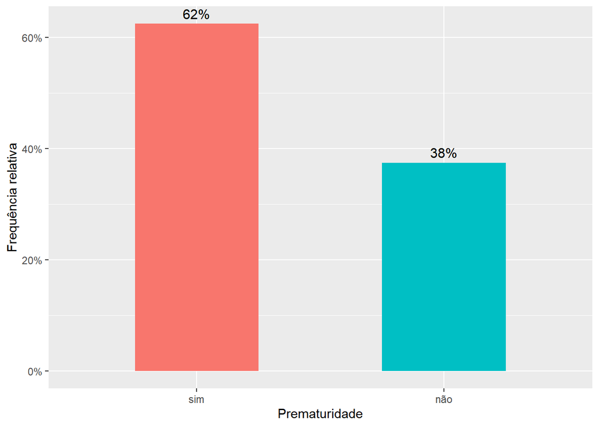

**Figura 1**: Taxa de prematuridade considerando todas as gestantes da amostra.

Como pode-se observar na *Figura 1*, de 336 mulheres que tiveram gestação de gemelares, em 62% delas o parto ocorreu antes de 37 semanas de gestação, ou seja, o parto ocorreu prematuramente. Além disso, o número de gestantes que tiveram o parto após 37 semanas de gestação foi de 38%, o que significa que os partos prematuros ocorreram consideravelmente mais vezes do que os partos após 37 semanas.

As 336 gestantes foram divididas em dois grupos, tendo um grupo recebido o tratamento com progesterona, e o outro sendo um grupo de controle sobre efeito placebo, como podemos ver na *Tabela 1*.

**Tabela 1**: Tabela de frequência dos grupos de tratamento ao qual as gestantes pertencem denotada pela variável ‘ovulos’:

|  | Freq | % |
| --- | --- | --- |
| **placebo** | 170 | 50.60 |
| **progesterona** | 166 | 49.40 |
| **Total** | 336 | 100.00 |

Estudos científicos mostram que existe uma relação entre a medida do colo uterino da gestante e o parto prematuro, e que o tratamento com progesterona nesses casos possui efeitos positivos para o retardamento da prematuridade. Além disso, sabe-se que a chance de partos prematuros ocorrerem em gestação de gemelares é bastante alta *ver Figura 1*. O tratamento com progesterona teve efeito positivo para que a taxa de partos prematuros fosse menor que a de partos que ocorreram após 37 semanas ?

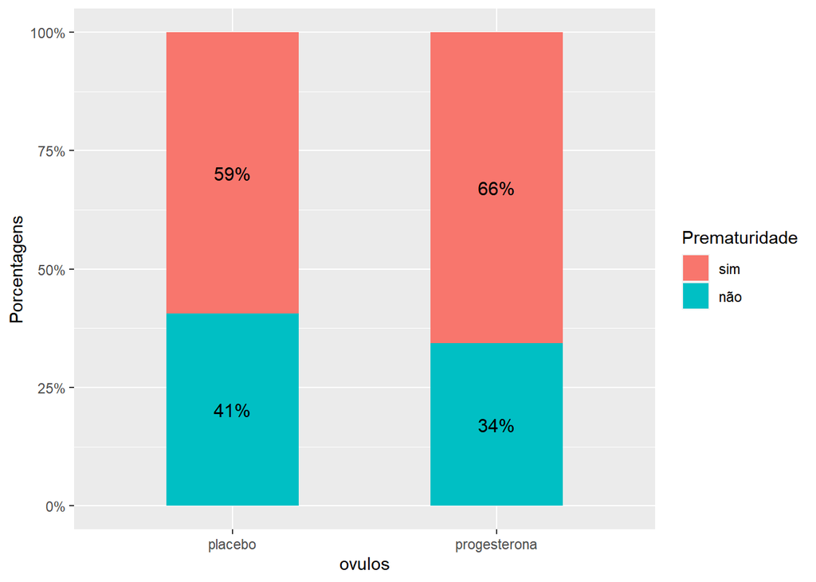

**Figura 2**: Taxa de prematuridade por grupos (placebo e progesterona).

A *Figura 2* sugere que houve uma taxa de partos prematuros maior que não prematuros em ambos os grupos, havendo um peso maior de prematuros no grupo que recebeu tratamento de progesterona. Em primeiro momento as informações do gráfico parecem ir contra os estudos feitos sobre o efeito da progesterona.

Gestações de gemelares podem ser classificadas como monocoriônicas ou dicoriônicas dependendo do número de placentas. Existem importantes complicações que surgem apenas em casos classificados como monocoriônicas pois nesses casos existe o compartilhamento da placenta entre os fetos. Segue abaixo a frequência de cada grupo:

**Tabela 2**: Tabela de frequência para corionicidade:

|  | Freq | % |
| --- | --- | --- |
| **monocoriônica** | 71 | 21.45 |
| **dicoriônica** | 260 | 78.55 |
| **Total** | 331 | 100.00 |

Podemos ver que a maioria dos casos da amostra são dicoriônicos 78.55%, porém 21.45% de casos monocoriônicos é um número considerável. A corionicidade afeta a taxa de prematuridade ?

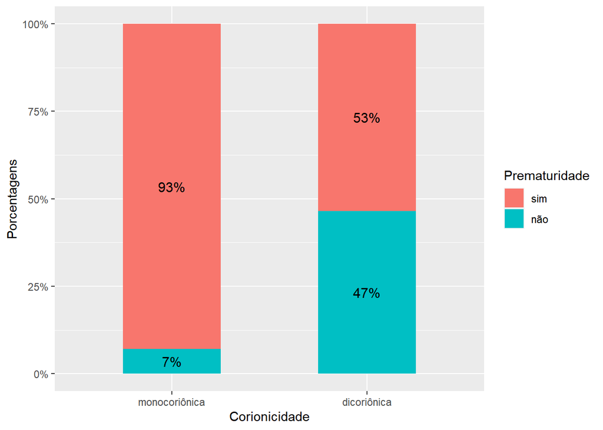

**Figura 3**: Taxa de prematuridade por corionicidade.

Como podemos ver, a taxa de prematuridade em gestações dicoriônicas ficou por volta de 50% dos casos, porém o que realmente preocupa são os 93% das gestações monocoriônicas os quais resultaram em parto prematuro, valores altos nesse tipo de gestação são esperados considerando as complicações que podem surgir nas gestações com esta classificação, mas ainda são valores preocupantes.

E se olharmos para a variável ‘cor’, será que ser branco ou não possui alguma relação para que o parto seja prematuro ? primeiro iremos olhar a frequência dessa variável na amostra e então buscaremos pistas para esta pergunta.

**Tabela 3**: Tabela de frequência para cor (cor branca: sim ou não):

|  | Freq | % |
| --- | --- | --- |
| **não** | 151 | 45.90 |
| **sim** | 178 | 54.10 |
| **Total** | 329 | 100.00 |

Vemos que o número de gestantes brancas e não brancas é bem próximo, embora gestantes brancas estejam em maior número.

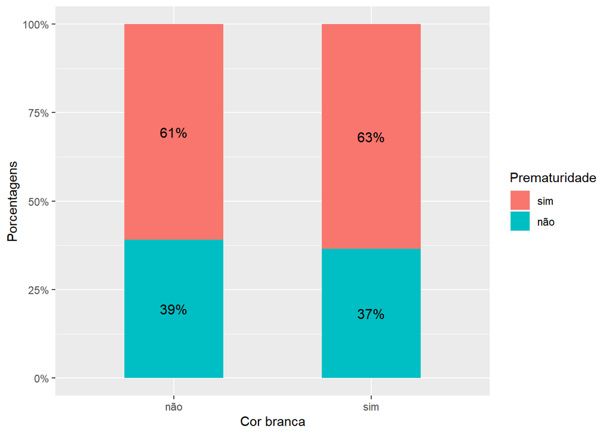

**Figura 4**: Taxa de prematuridade pela cor (cor branca: sim ou não).

O gráfico sugere um certo equilibrio nas taxas de prematuridade seja a cor branca ou não.

O que podemos dizer sobre a idade das getantes ?

**Tabela 4**: Medidas descritivas da idade das gestantes.

|  | im |
| --- | --- |
| **Média** | 28.38 |
| **Desv.padrão** | 6.08 |
| **Mín** | 15.00 |
| **Q1** | 24.00 |
| **Med** | 28.00 |
| **Q3** | 32.00 |
| **Máx** | 47.00 |
| **MDA** | 5.93 |
| **IQE** | 8.00 |
| **CV** | 0.21 |
| **Assimetria** | 0.12 |
| **EP.Assimetria** | 0.13 |
| **Curtose** | -0.52 |
| **N.Válidos** | 336.00 |
| **Pct.Válidos** | 100.00 |

Nota-se que a menor idade que encontra-se na amostra é de 15 anos, enquanto que a maior é de 47 anos. Além disso, a idade média é de 28.38 anos (com desvio padrão de 6.08), valor bem próximo da mediana. Olhando para os quartis, observa-se que 25% das gestantes possuem menos que 24 anos, 25% delas possuem mais que 32 anos, e 50% possuem entre 24 e 32 anos.

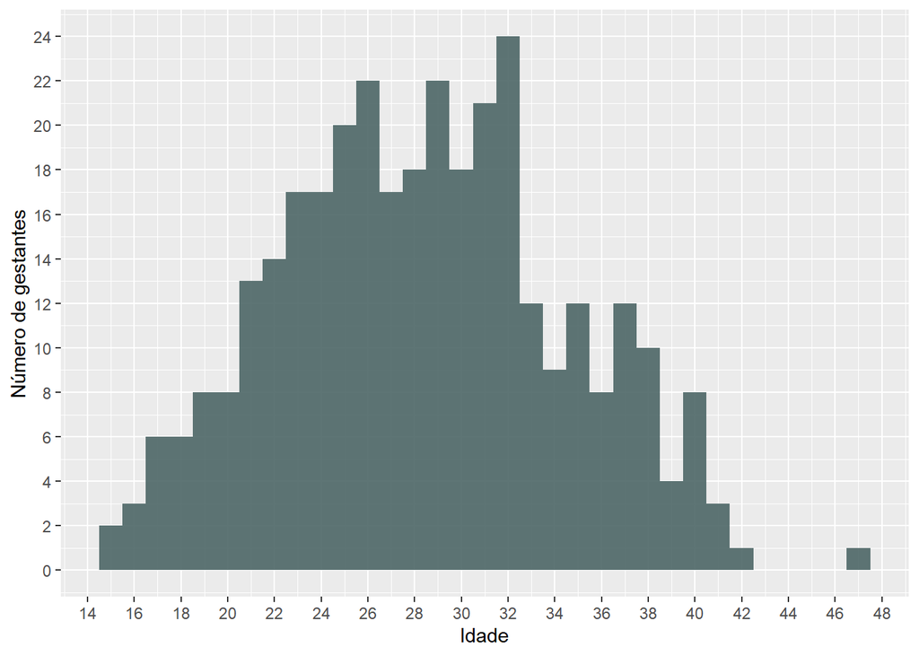

**Figura 5**: Histograma da idade das gestantes.

No histograma acima temos um valor um pouco distante em que a idade = 47 anos. Vale ressaltar que a média e a mediana são valores bastante próximos, além disso o valor da média e desvio padrão sem esse valor “extremo” são de 28.32 e 6.01 respectivamente, ou seja, esse valor sozinho não teve muito impacto nas medidas.

A idade das gestantes possui alguma influência na quantidade de partos prematuros ?

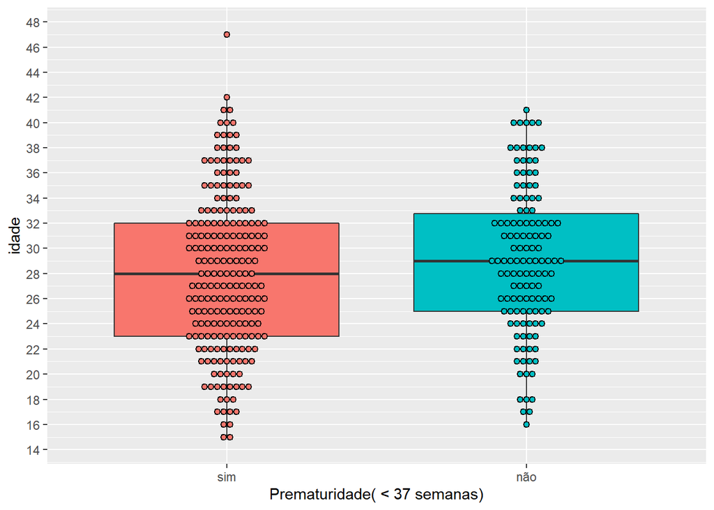

**Figura 6**: Boxplot do indicador de prematuridade( < 37 semanas) e a idade das gestantes (dotplot dos dados incluso).

Como esperado, o número de pontos no grupo de partos prematuros parece ser maior que no de não prematuros como também foi indicado na *Figura 1*. Embora houve mais gestantes que tiveram partos prematuros, a idade delas não difere muito nos dois grupos. Observa-se que a mediana nos dois grupos são extramamente próximas, diferindo em apenas uma unidade, e ambos parecem possuir uma distribuição mais ou menos simétrica com o primeiro grupo sendo levemente mais disperso que o segundo pelo intervalo interquartílico. Visto isso, há uma proximidade das medidas de ambos os grupos que em um primeiro momento sugerem não haver uma associação com a idade das gestantes e o número de partos prematuros.

Pode-se observar essa proximidade das medidas da idade das gestantes pelos grupos (prematuridade: sim ou não) no output abaixo:

```
$sim
   Min. 1st Qu.  Median    Mean 3rd Qu.    Max.
  15.00   23.00   28.00   27.97   32.00   47.00

$não
   Min. 1st Qu.  Median    Mean 3rd Qu.    Max.
  16.00   25.00   29.00   29.06   32.75   41.00
```

Agora vamos ver um pouco sobre o tempo de ecolaridade registrado pelas gestantes.

**Tabela 5**: Medidas descritivas do tempo de escolaridade (em anos) das gestantes.

|  | tescola |
| --- | --- |
| **Média** | 10.46 |
| **Desv.padrão** | 2.34 |
| **Mín** | 4.00 |
| **Q1** | 9.00 |
| **Med** | 11.00 |
| **Q3** | 11.00 |
| **Máx** | 14.00 |
| **MDA** | 1.48 |
| **IQE** | 1.50 |
| **CV** | 0.22 |
| **Assimetria** | -0.29 |
| **EP.Assimetria** | 0.13 |
| **Curtose** | -0.36 |
| **N.Válidos** | 336.00 |
| **Pct.Válidos** | 100.00 |

Podemos ver que o menor tempo de escolaridade foi de 4 anos, enquanto que as gestantes que tiveram o maior tempo frequentaram a escola por 14 anos. Olhando para os quartis, 25% das gestantes tiveram menos do que 9 anos de tempo de escolaridade, 50% delas entre 9 e 11 anos, e 25% entre 11 e 14 anos. Além disso, o tempo médio foi de 10.46 anos (desvio padrão de 2.34), valor próximo a mediana a qual foi de 11 anos.

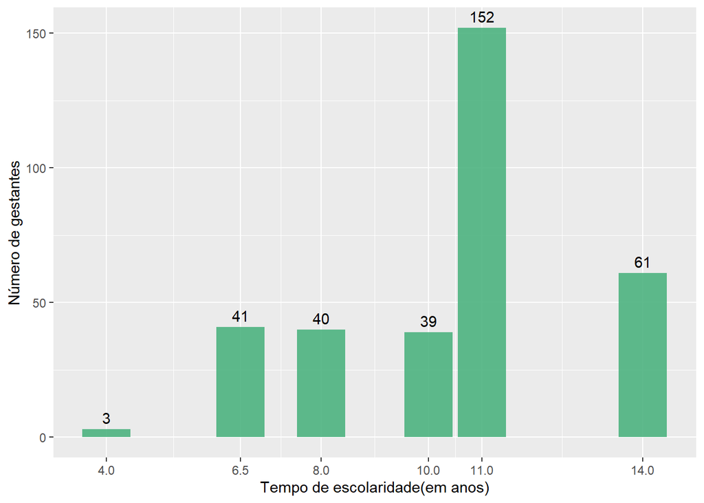

**Figura 7**: Gráfico do tempo de ecolaridade (em anos) das gestantes.

Na *Figura 7* observamos que a maioria teve 11 anos de tempo escolar, sendo 152 gestantes de um total de 336. 11 anos é o equivalente ao tempo do ensino fundamental e médio, olhando pela perpectiva de grau de instrução e considerando não repetentes, isso seria dizer que 152 de 336 gestantes tiveram tempo de escolaridade equivalente ao tempo de conclusão de ensino médio. Considerando que o ensino fundamental no Brasil vai até em torno de 8 ou 9 anos, 44 gestantes não terminaram o ensino fundamental. Além disso, 61 gestantes registraram 14 anos de escolaridade, talvez incluso anos repetidos ou pessoas que tiveram instrução além do ensino médio.

Obs: Apenas 6 valores foram registrados como tempo de escolaridade, sendo o valor de 6.5 o único não inteiro.

O peso pré-gestacional afeta o número de partos prematuros ?

**Tabela 6**: Medidas descritivas do peso pré-gestacional das gestantes.

|  | peso_pre |
| --- | --- |
| **Média** | 64.94 |
| **Desv.padrão** | 14.25 |
| **Mín** | 36.00 |
| **Q1** | 55.00 |
| **Med** | 63.00 |
| **Q3** | 72.00 |
| **Máx** | 115.00 |
| **MDA** | 11.86 |
| **IQE** | 17.00 |
| **CV** | 0.22 |
| **Assimetria** | 0.95 |
| **EP.Assimetria** | 0.14 |
| **Curtose** | 0.94 |
| **N.Válidos** | 326.00 |
| **Pct.Válidos** | 97.02 |

Observamos que o peso pré-gestacional médio das gestantes foi de praticamente 65Kg com desvio padrão de 14.25, valor de 2Kg a mais que a mediana. O menor peso registrado foi de 36Kg, e o maior foi de 115Kg. Olhando para os quartis, vemos que 25% das gestantes tinham peso pré-gestacional de até 55Kg, 25% pesavam mais que 72Kg, e os outros 50% pesavam entre 55Kg e 72Kg.

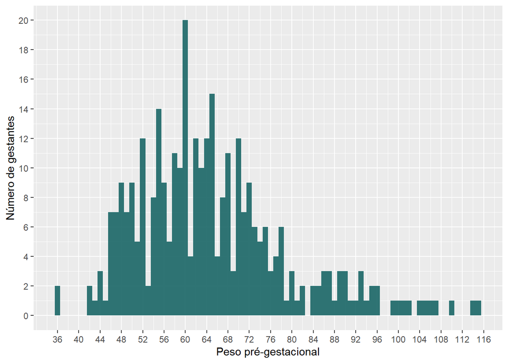

**Figura 8**: Histograma do peso pré-gestacional das gestantes.

Podemos observar que os pesos mais frequentes estão mais concentrados no lado esquerdo do gráfico próximos aos valores de tendência central, média, mediana, e o valor 60 o qual é a moda, e a frequência diminui quando o peso aumenta indicando uma assimetria à direita na distribuição, comportamento esperado quando se tratando de pesos.

Será que o peso pré-gestacional tem alguma influência nas taxas de prematuridade ?

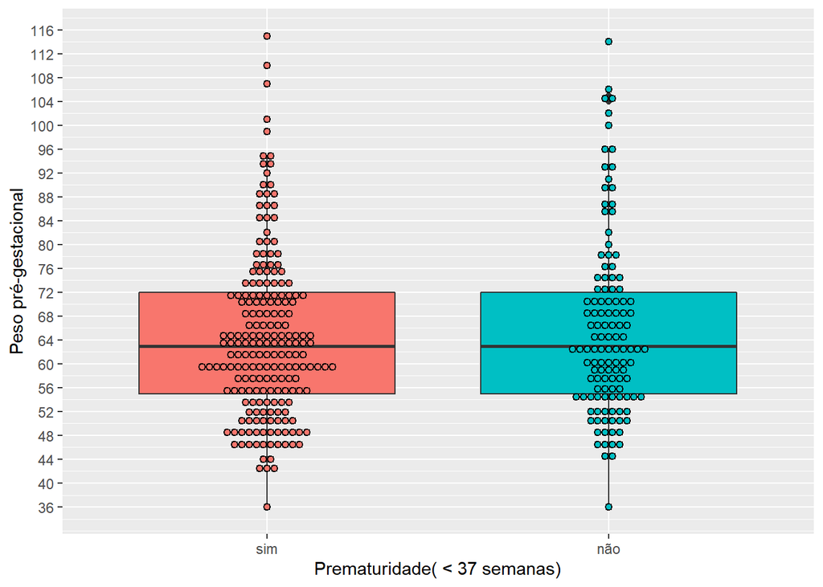

**Figura 9**: Boxplot do indicador de prematuridade( < 37 semanas) e o peso pré-gestacional das gestantes (dotplot dos dados incluso).

O boxplot acima sugere que mesmo havendo mais casos prematuros na amostra, o peso pré-gestacional não está tendo influência nesses valores.

Olhando para a altura das gestantes agora, temos o seguinte:

**Tabela 7**: Medidas descritivas da altura das gestantes.

|  | alt |
| --- | --- |
| **Média** | 1.61 |
| **Desv.padrão** | 0.06 |
| **Mín** | 1.43 |
| **Q1** | 1.57 |
| **Med** | 1.60 |
| **Q3** | 1.65 |
| **Máx** | 1.83 |
| **MDA** | 0.06 |
| **IQE** | 0.08 |
| **CV** | 0.04 |
| **Assimetria** | 0.07 |
| **EP.Assimetria** | 0.14 |
| **Curtose** | 0.31 |
| **N.Válidos** | 307.00 |
| **Pct.Válidos** | 91.37 |

A *Tabela 7* mostra que a altura média das gestantes é de 1.61m com desvio padrão de 0.06, valor extremamente próximo da mediana. As medidas variam de 1.43m à 1.83m, sendo 25% das gestantes tendo até 1.57m, 25% mais que 1.65m, e os outros 50% entre 1.57m e 1.65m.

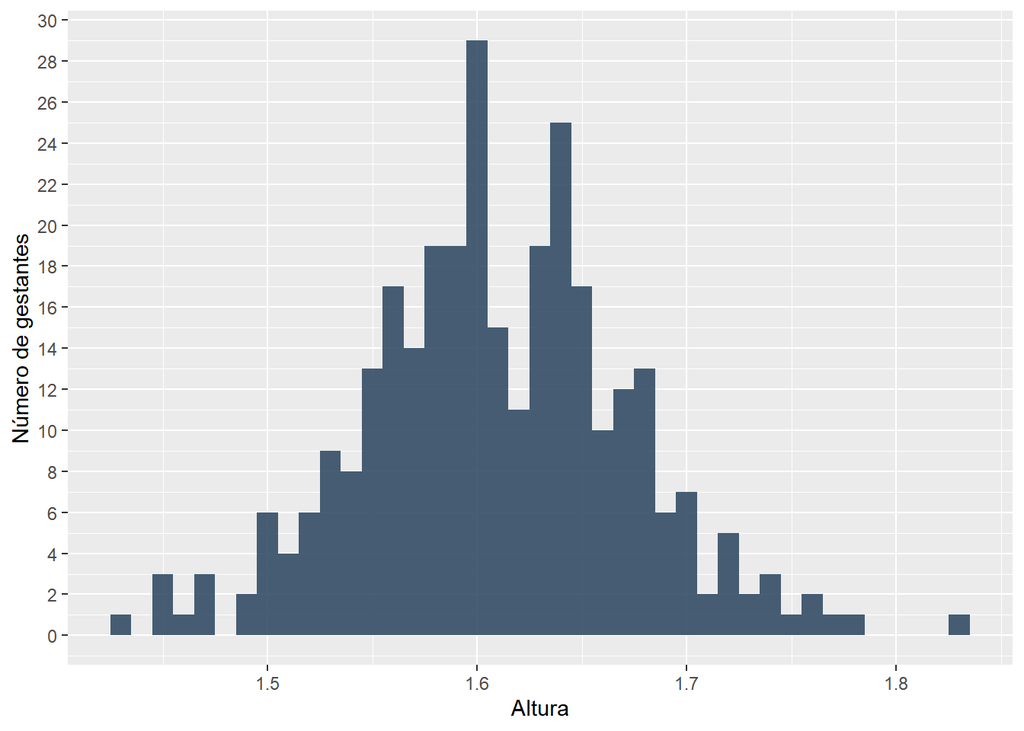

**Figura 10**: Histograma da altura das gestantes.

Observamos aqui dados mais distribuidos igualmente ao redor das medidas de tendência central, o que faz sentido dado uma assimetria de 0.07. Formato comum para uma distribuição de alturas.

Será que a altura das gestantes tem alguma influência nas taxas de prematuridade ?

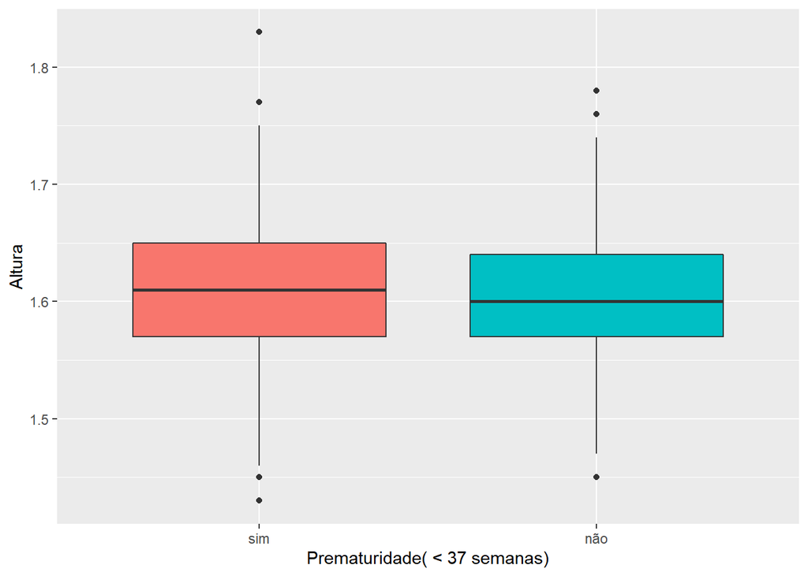

**Figura 11**: Boxplot do indicador de prematuridade( < 37 semanas) e a altura das gestantes.

Notamos que há uma sutil diferença na altura das caixa do gráfico acima, porém uma diferença muito pequena, o que sugere que não há uma influência expressiva da altura das gestantes nas quantidades de partos prematuros.

Tendo explorado o peso pré-gestacional e altura, faz sentido agora explorarmos o IMC pré gestacional, dado que este utiliza essas duas variáveis para seu cálculo.

**Tabela 8**: Medidas descritivas do IMC pré-gestacional das gestantes.

|  | imc |
| --- | --- |
| **Média** | 25.12 |
| **Desv.padrão** | 4.94 |
| **Mín** | 15.62 |
| **Q1** | 21.67 |
| **Med** | 24.09 |
| **Q3** | 27.40 |
| **Máx** | 42.04 |
| **MDA** | 4.04 |
| **IQE** | 5.73 |
| **CV** | 0.20 |
| **Assimetria** | 0.90 |
| **EP.Assimetria** | 0.14 |
| **Curtose** | 0.71 |
| **N.Válidos** | 305.00 |
| **Pct.Válidos** | 90.77 |

Observmos um IMC médio de 25.12 (desvio padrão de 4.94), valor próximo da mediana. IMC mínimo de 15.62 e máximo de 42.04, sendo 25% das gestantes com IMC de até 21.67, 25% com IMC maior que 27.4, e os outros 50% com IMC entre 21.67 e 27.4.

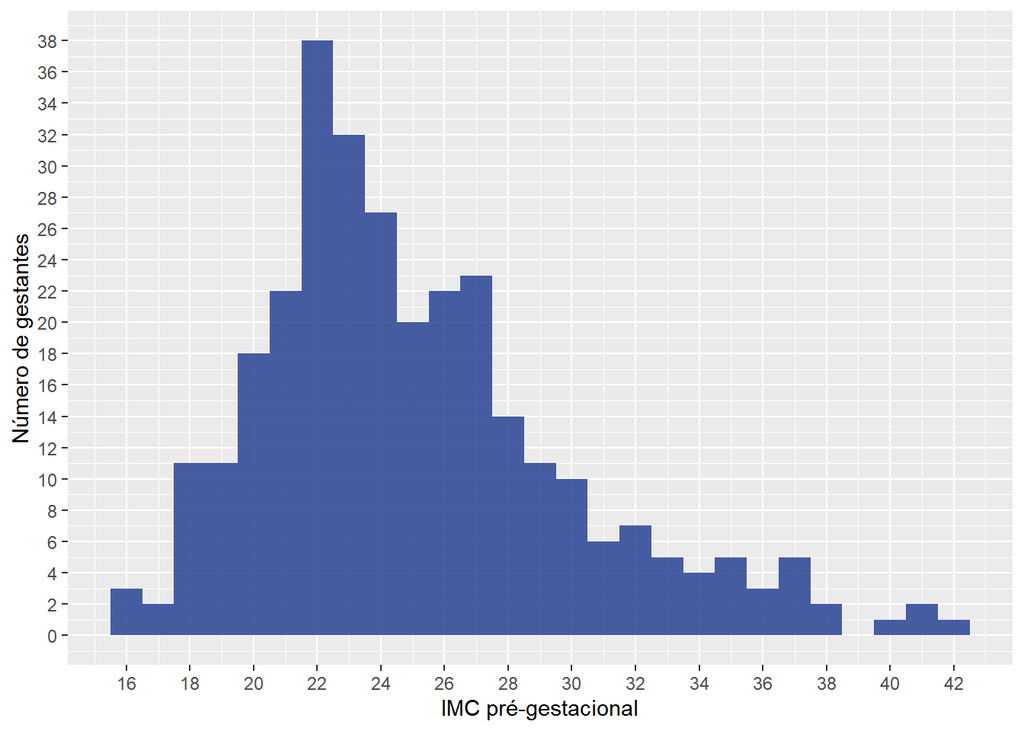

É evidente a assimetria à direita na distribuição, sendo os IMCs mais frequentes registrados com valores por volta de 22 e 23.

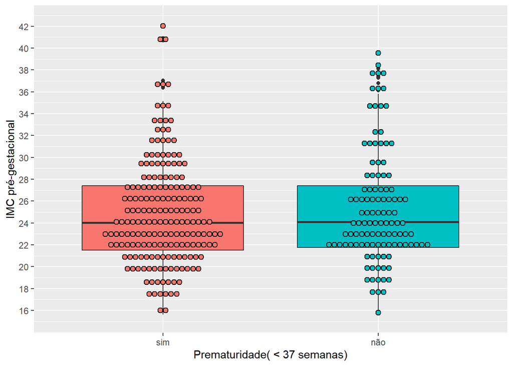

**Figura 13**: Boxplot do indicador de prematuridade( < 37 semanas) e o IMC pré-gestacional das gestantes (dotplot dos dados incluso).

Como mostra o boxplot acima, o IMC não parece estar influenciando no número de partos prematuros, visto que a posição das caixas são extremamente similares.

É de conhecimento popular que o uso de drogas durante a gravidez pode trazer prejuízos a gestante e a criança. Na amostra que possuímos temos registros em três variáveis que identificam se a gestante é fumante, se consome álcool, ou se usa drogas, podemos ver as frequências dessas variáveis nas tabelas a seguir.

**Tabela 9A**: Tabela de frequência para tabagismo.

|  | Freq | % |
| --- | --- | --- |
| **não** | 305 | 90.77 |
| **sim** | 31 | 9.23 |
| **Total** | 336 | 100.00 |

**Tabela 9B**: Tabela de frequência para etilista.

|  | Freq | % |
| --- | --- | --- |
| **não** | 333 | 99.11 |
| **sim** | 3 | 0.89 |
| **Total** | 336 | 100.00 |

**Tabela 9C**: Tabela de frequência para usuário de drogas.

|  | Freq | % |
| --- | --- | --- |
| **não** | 333 | 99.11 |
| **sim** | 3 | 0.89 |
| **Total** | 336 | 100.00 |

Vemos que o número de gestantes que faz parte de algum dos três grupos é pequena na amostra, sendo apenas 9.23% das gestantes fumantes, 0.89% consomem álcool, e também 0.89% usam drogas.

Seja fumante, se consome álcool ou se usa drogas, alguma dessas variáveis teve algum efeito no número de casos de partos prematuros observados ?

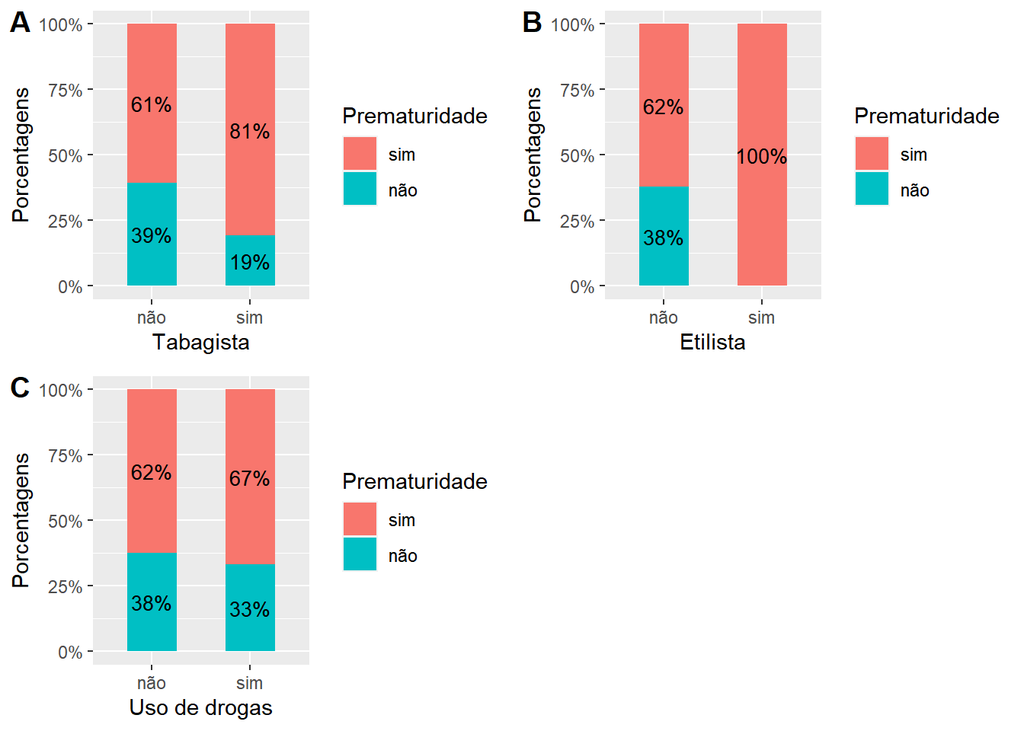

**Figura 14A**: Gráfico de barras para ‘tabagismo’ e ‘prematuridade’.

**Figura 14B**: Gráfico de barras para ‘etilista’ e ‘prematuridade’.

**Figura 14C**: Gráfico de barras para ‘uso de drogas’ e ‘prematuridade’.

Primeiro vemos que a taxa de gestantes que tiveram parto prematuro é maior do que as que não tiveram parto prematuro em todos os três casos, resultado esperado para uma amostra de gestação de gemelares. Vemos na *Figura 14A* que a taxa de partos prematuros foi maior em gestantes que fumavam. Na *Figura 14B* 100% das gestantes que consumiam álcool tiveram parto prematuro, mas vale lembrar que de 336 gestantes apenas 3 consumiam álcool *ver Tabela 9B*. E por último na *Figura 14C* vemos taxas mais equilibradas nos dois grupos, porém aqui também são apenas 3 gestantes de 336 que usam drogas.

Iremos agora investigar outras 4 variáveis de suma importância:

**Tabela 10A**: Tabela de frequência para variável ‘primigesta’.

|  | Freq | % |
| --- | --- | --- |
| **não** | 220 | 65.48 |
| **sim** | 116 | 34.52 |
| **Total** | 336 | 100.00 |

**Tabela 10B**: Tabela de frequência para variável ‘primipara’.

|  | Freq | % |
| --- | --- | --- |
| **não** | 208 | 61.90 |
| **sim** | 128 | 38.10 |
| **Total** | 336 | 100.00 |

**Tabela 10C**: Tabela de frequência para variável ‘aborto’.

|  | Freq | % |
| --- | --- | --- |
| **não** | 258 | 77.25 |
| **sim** | 76 | 22.75 |
| **Total** | 334 | 100.00 |

**Tabela 10D**: Tabela de frequência para variável indicadora de doenças prévias ‘ind_ap’.

|  | Freq | % |
| --- | --- | --- |
| **não** | 249 | 74.11 |
| **sim** | 87 | 25.89 |
| **Total** | 336 | 100.00 |

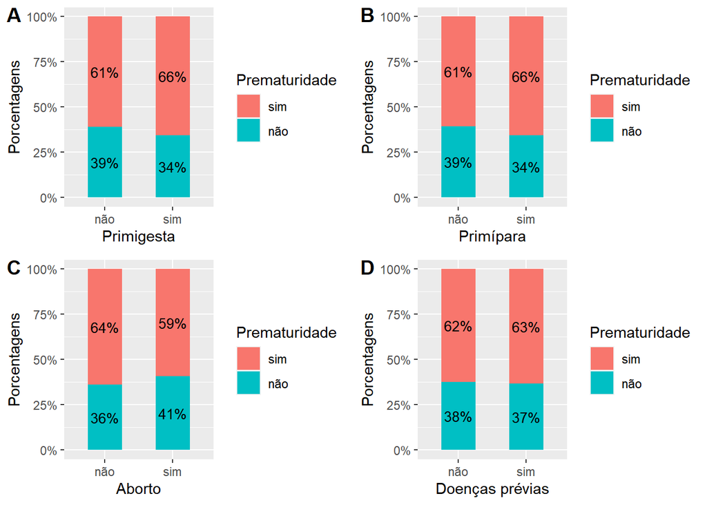

**Figura 15A**: Gráfico de barras para ‘primigesta’ e ‘prematuridade’.

**Figura 15B**: Gráfico de barras para ‘primípara’ e ‘prematuridade’.

**Figura 15C**: Gráfico de barras para ‘aborto’ e ‘prematuridade’.

**Figura 15D**: Gráfico de barras para ‘doenças prévias’ e ‘prematuridade’.

Nas quatro variáveis em questão não parece ter havido uma grande influência no número de partos prematuros, ambos os grupos de partos (prematuros e não prematuros) estão bem equilibrados em seus valores sem grandes discrepâncias.

## Variáveis funcionais

A amostra possui duas variáveis funcionais, sendo a ‘medida_colo’ as medidas registradas do colo uterino das gestantes no decorrer do pré-natal, e o ‘num_contra’ que é o numero de contrações registrados também no decorrer do pré-natal. Vamos agora explorar essas variáveis.

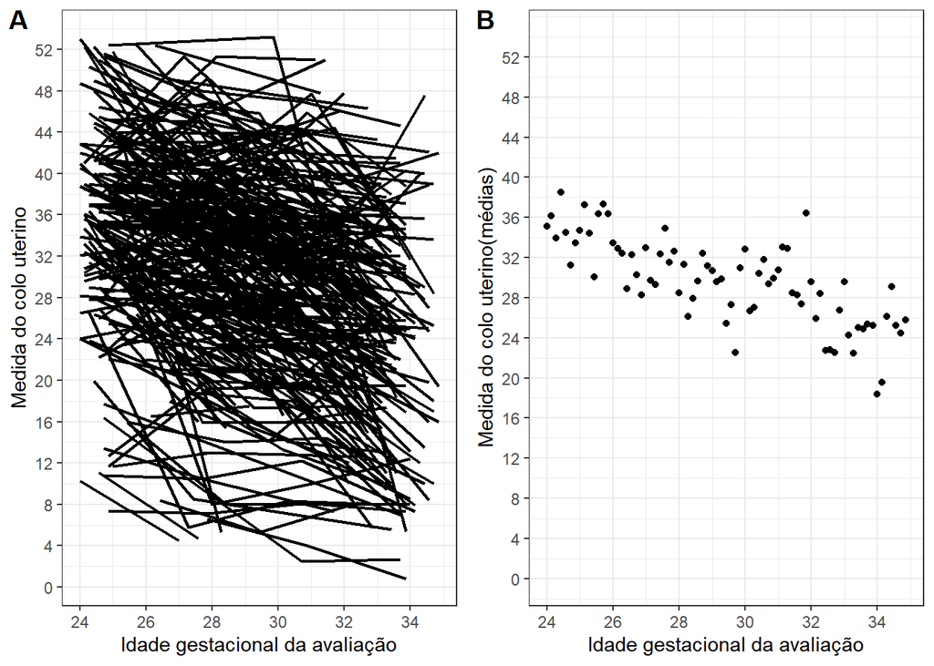

**Figura 16A**: Gráfico de perfis individuais da medida do colo uterino das gestantes.

**Figura 16B**: Gráfico de dispersão das médias das medidas do colo uterino de todas as gestantes na mesma idade gestacional.

As *Figuras 16A e 16B* sugerem uma certa diminuição do comprimento do colo uterino das gestantes no decorrer da gestação, o que é esperando sabendo que o corpo da gestante como forma de preparação para o parto tende a diminuir a medida do colo uterino para facilitar o nascimento do bebê.

Obs: Figuras como a *Figura 16B* foram feitas utilizando a média das medidas da variável em questão de todas as gestantes na determinada idade gestacional truncada sem filtros (e também foram aplicadas nos dados “crus”, sem imputação), logo são figuras apenas por questões de curiosidade e obtenção de “insights”.

Abaixo vemos a mesma informação da *Figura 16B* por grupos (placebo e progesterona).

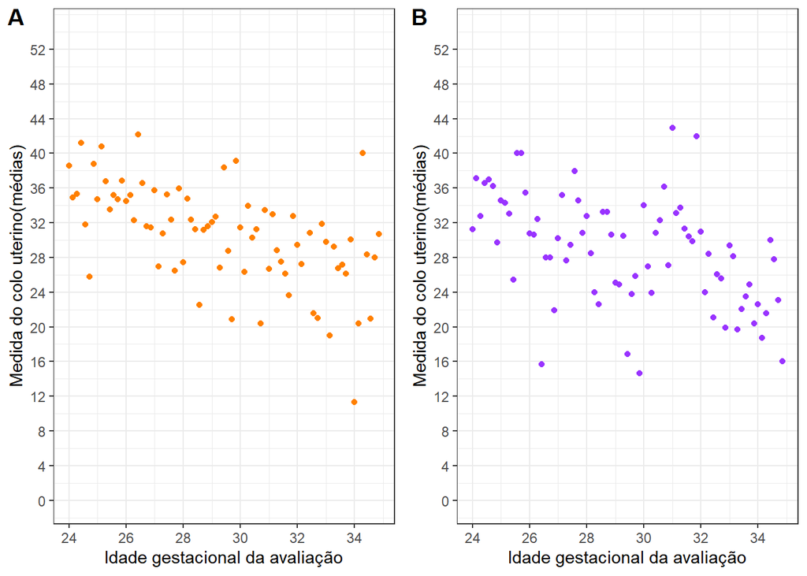

**Figura 17A**: Gráfico de dispersão das médias das medidas do colo uterino de todas as gestantes na mesma idade gestacional pertencentes ao grupo de tratamento placebo.

**Figura 17B**: Gráfico de dispersão das médias das medidas do colo uterino de todas as gestantes na mesma idade gestacional que tiveram tratamento com progesterona.

Em um primeiro momento a dispersão do grupo do tratamento de progesterona parece ter uma variabilidade maior ao longo das avaliações se comparado com a dispersão do grupo de placebo.

Qual será o comportamento da medida do colo uterino das gestantes que tiveram parto prematuro ? e das gestantes que não tiveram parto prematuro ?

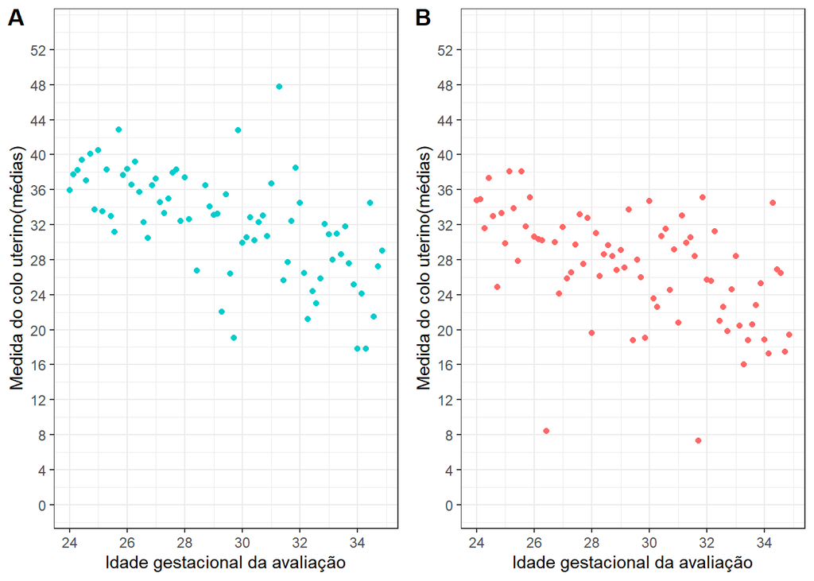

**Figura 18A**: Gráfico de dispersão das médias das medidas do colo uterino de todas as gestantes na mesma idade gestacional que não tiveram parto prematuro.

**Figura 18B**: Gráfico de dispersão das médias das medidas do colo uterino de todas as gestantes na mesma idade gestacional que tiveram parto prematuro.

É possível perceber uma diferença na altura dos pontos dos gráficos acima, a dispersão das médias das medidas do colo uterino das gestantes que tiveram parto prematuro parece estar mais concentrada em medidas menores se comparada com as que não tiveram parto prematuro.

Iremos agora fazer a mesma análise feita para a medida do colo (também utilizando dados sem nenhuma imputação), porém agora com o número de contrações registrados ao longo da idade gestacional da gestante.

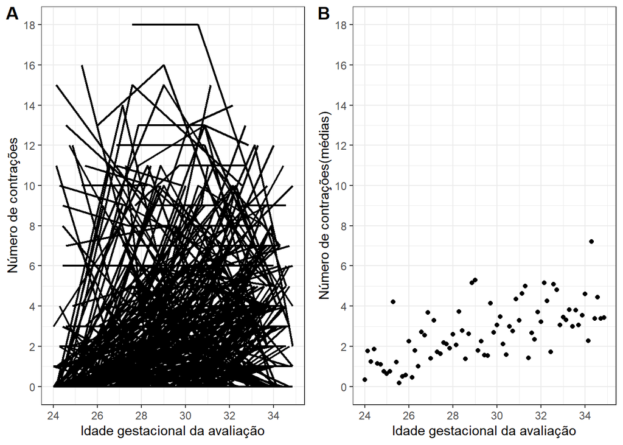

**Figura 19A**: Gráfico de perfis individuais do número de contrações das gestantes.

**Figura 19B**: Gráfico de dispersão das médias do número de contrações de todas as gestantes na mesma idade gestacional.

Como esperado, o número de contrações tende a aumentar no decorrer das avaliações e aproximação do parto.

Abaixo vemos a mesma informação da Figura 19B por grupos (placebo e progesterona).

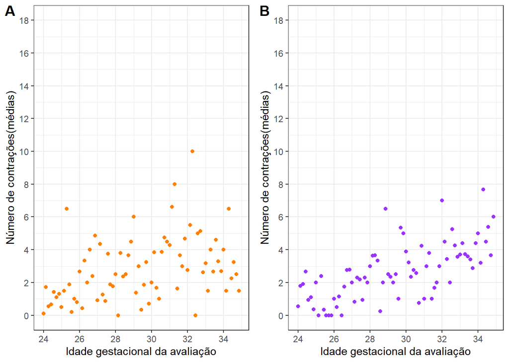

**Figura 20A**: Gráfico de dispersão das médias do número de contrações de todas as gestantes na mesma idade gestacional pertencentes ao grupo de tratamento placebo.

**Figura 20B**: Gráfico de dispersão das médias do número de contrações de todas as gestantes na mesma idade gestacional que tiveram tratamento com progesterona.

Aqui também não aparenta haver grandes diferenças, porém vale ressaltar que o grupo de tratamento placebo parece estar um pouco mais disperso na *Figura 20A*.

Qual será o comportamento do número de contrações das gestantes que tiveram parto prematuro ? e das gestantes que não tiveram parto prematuro ?

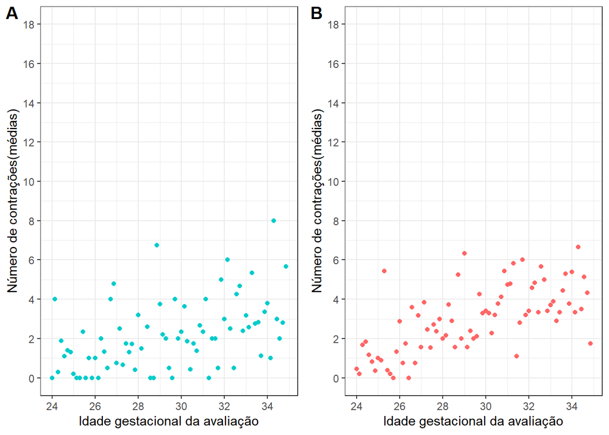

**Figura 21A**: Gráfico de dispersão das médias do número de contrações de todas as gestantes na mesma idade gestacional que não tiveram parto prematuro.

**Figura 21B**: Gráfico de dispersão das médias do número de contrações de todas as gestantes na mesma idade gestacional que tiveram parto prematuro.

A única diferença que parece existir é no quão disperso os dois casos são um do outro, sendo o número de contrações das gestantes que não tiveram parto prematuro um pouco mais disperso do que das gestantes que tiveram parto prematuro, embora a diferença não seja muito expressiva.

# Análise dos dados faltantes

Funções:

```r
getmode <- function(v) {
   which.max(tabulate(v))
}
```

##### Dados:

```r
dados <- read_excel("Base_TocoColoPerinatal.xls")
dados <- clean_names(dados)
names(dados)
```

```
 [1] "id"           "indic_aval"   "ig_aval"      "medida_colo"  "num_contra"
 [6] "ovulos"       "corion"       "im"           "tescola"      "cor_branco"
[11] "peso_pre"     "alt"          "imc"          "gesta"        "para"
[16] "a"            "ind_ap"       "hv_tabagismo" "hv_alcool"    "hv_drogas"
[21] "igp_parto"
```

```r
#Verifica a existência de valores que não deveriam existir nas
#variáveis ajustadas à essa função.

verifica_erro <- function(v){

  if(v %in% "ovulos"){
    any(as.data.frame(dados)$v != 1 & as.data.frame(dados)$v != 2)
  } else if(v %in% "corion"){
    any(as.data.frame(dados)$v != 1 & as.data.frame(dados)$v != 2)
  } else if(v != "ovulos"& v != "corion")
    any(as.data.frame(dados)$v != 0 & as.data.frame(dados)$v != 1)
}

list_var_names <- c(
  "ovulos",
  "corion",
  "cor_branco",
  "ind_ap",
  "hv_tabagismo",
  "hv_alcool",
  "hv_drogas")


sapply(list_var_names, verifica_erro)
```

```
      ovulos       corion   cor_branco       ind_ap hv_tabagismo    hv_alcool
       FALSE        FALSE        FALSE        FALSE        FALSE        FALSE
   hv_drogas
       FALSE
```

```r
dados$medida_colo[dados$medida_colo == 0] <- NA

dados$ovulos <- fct_recode(
  as.factor(dados$ovulos),
  placebo = "1",
  progesterona = "2")

dados$corion <- fct_recode(
  as.factor(dados$corion),
  "monocoriônica" = "1",
  "dicoriônica" = "2")

dados[c("cor_branco",
        "ind_ap",
        "hv_tabagismo",
        "hv_alcool",
        "hv_drogas")] <-
  lapply(dados[c("cor_branco",
                 "ind_ap",
                 "hv_tabagismo",
                 "hv_alcool",
                 "hv_drogas")],
         factor,
         levels = c(0,1),
         labels = c("não","sim"))

dados$ig_aval_sem <- trunc(dados$ig_aval)
```

### Variáveis fixas

Vamos primeiro analisar as variáveis fixas.

```r
dados_fixas <- dados %>%
  filter(indic_aval == 1)  %>%
  select(-indic_aval,
         -ig_aval,
         -medida_colo,
         -num_contra,
         -imc,
         -ig_aval_sem,
         -imc)
```

Vi que há 2 dados faltantes em aborto (`a`), mas não há em gesta e nem em partos.

Uma coisa para mudar na base: `a` (aborto) é igual a gestações menos parto e menos 1.

```r
dados_fixas$a[is.na(dados_fixas$a)] <- dados_fixas$gesta[is.na(dados_fixas$a)] -  dados_fixas$para[is.na(dados_fixas$a)] - 1
```

Vamos criar uma variável auxiliar para ver o número de gestações ao considerar partos mais abortos e mais um (a gestação atual).

```r
aux <- dados_fixas$para + dados_fixas$a + 1
```

Mas note que para alguns casos (7 casos) o número de gestações (`gesta`) não é igual à variável auxiliar. Corrigimos isso no que segue:

```r
dados_fixas <- dados_fixas %>%
  mutate(gesta = para + a + 1)
```

Vamos agora ver as variáveis fixas que tem valores ausentes.

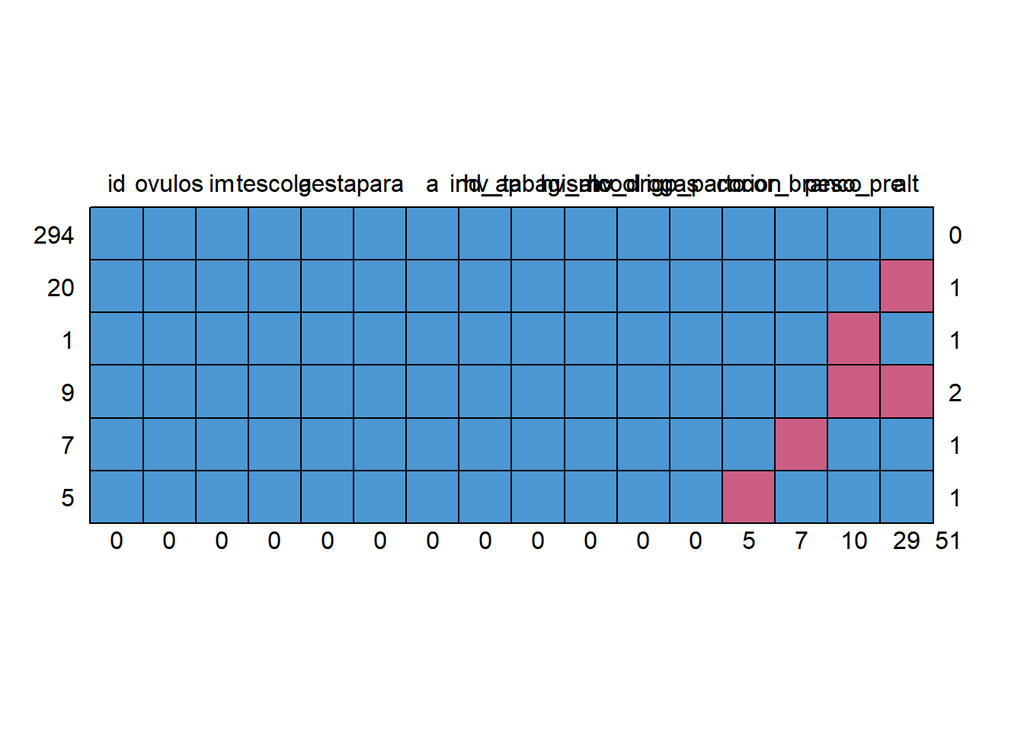

```
    id ovulos im tescola gesta para a ind_ap hv_tabagismo hv_alcool hv_drogas
294  1      1  1       1     1    1 1      1            1         1         1
20   1      1  1       1     1    1 1      1            1         1         1
1    1      1  1       1     1    1 1      1            1         1         1
9    1      1  1       1     1    1 1      1            1         1         1
7    1      1  1       1     1    1 1      1            1         1         1
5    1      1  1       1     1    1 1      1            1         1         1
     0      0  0       0     0    0 0      0            0         0         0
    igp_parto corion cor_branco peso_pre alt
294         1      1          1        1   1  0
20          1      1          1        1   0  1
1           1      1          1        0   1  1
9           1      1          1        0   0  2
7           1      1          0        1   1  1
5           1      0          1        1   1  1
            0      5          7       10  29 51
```

```r
md.pattern(dados_fixas)
```

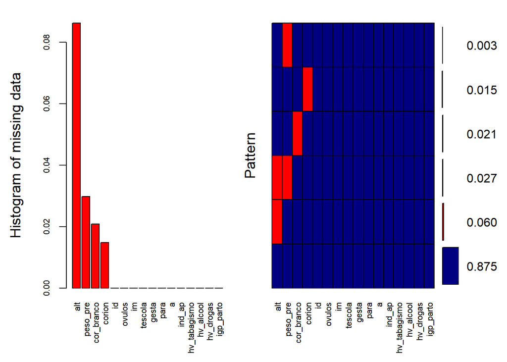

```
 Variables sorted by number of missings:
     Variable      Count
          alt 0.08630952
     peso_pre 0.02976190
   cor_branco 0.02083333
       corion 0.01488095
           id 0.00000000
       ovulos 0.00000000
           im 0.00000000
      tescola 0.00000000
        gesta 0.00000000
         para 0.00000000
            a 0.00000000
       ind_ap 0.00000000
 hv_tabagismo 0.00000000
    hv_alcool 0.00000000
    hv_drogas 0.00000000
    igp_parto 0.00000000
```

```r
aggr_plot <-
  aggr(
    dados_fixas,
    col = c('navyblue', 'red'),
    numbers = TRUE,
    sortVars = TRUE,
    labels = names(dados_fixas),
    cex.axis = .7,
    gap = 3,
    ylab = c("Histogram of missing data", "Pattern")
  )
```

Usamos o método MICE para imputar os dados faltantes para as variáveis fixas.

```r
mice_dados_fixas <-
  mice(
    dados_fixas,
    m = 10,
    maxit = 50,
    meth = 'pmm',
    seed = 500
  )
```

```r
aux_dados_fixas <- complete(mice_dados_fixas, "all",  mild = TRUE)

sem <- c("corion", "cor_branco", "peso_pre", "alt")

nrep <- c("1", "2", "3", "4", "5", "6", "7", "8", "9", "10")

aux <- matrix(0, nrow = dim(dados_fixas)[1], ncol = length(sem))
for (i in 1:2) {
  out <- aux_dados_fixas[[nrep[1]]][[sem[i]]]
  for (j in 2:length(nrep)) {
    out <- cbind(out, aux_dados_fixas[[nrep[j]]][[sem[i]]])
  }
  for (k in 1:dim(dados_fixas)[1]) {
    aux[k, i] <- getmode(out[k, ])
  }
}
for (i in 3:4) {
  out <- matrix(0, ncol = 1, nrow = dim(dados_fixas)[1])
  for (j in 1:length(nrep)) {
    out <- aux_dados_fixas[[nrep[j]]][[sem[i]]] + out
  }
  aux[, i] <- out / length(nrep)
}

dados_fixas_completo <-
  data.frame(
    id = aux_dados_fixas[["1"]][["id"]],
    ovulos = aux_dados_fixas[["1"]][["ovulos"]],
    corion = aux[, 1],
    im = aux_dados_fixas[["1"]][["im"]],
    tescola = aux_dados_fixas[["1"]][["tescola"]],
    cor_branco = aux[, 2],
    peso_pre = aux[, 3],
    alt = aux[, 4],
    gesta = aux_dados_fixas[["1"]][["gesta"]],
    para = aux_dados_fixas[["1"]][["para"]],
    a = aux_dados_fixas[["1"]][["a"]],
    ind_ap = aux_dados_fixas[["1"]][["ind_ap"]],
    hv_tabagismo = aux_dados_fixas[["1"]][["hv_tabagismo"]],
    hv_alcool = aux_dados_fixas[["1"]][["hv_alcool"]],
    hv_drogas = aux_dados_fixas[["1"]][["hv_drogas"]],
    igp_parto = aux_dados_fixas[["1"]][["igp_parto"]]
  )

dados_fixas_completo$corion <-
  fct_recode(
    as.factor(dados_fixas_completo$corion),
    "monocoriônica" = "1",
    "dicoriônica" = "2"
  )

dados_fixas_completo$cor_branco <-
  fct_recode(
    as.factor(dados_fixas_completo$cor_branco),
    "não" = "1",
    "sim" = "2"
  )

dados_fixas_completo <- dados_fixas_completo %>%
  mutate(imc = peso_pre / (alt ^ 2))
```

Agora vamos criar uma base concatenando as variáveis longitudinais e também as variáveis fixas, mas agora com a imputação.

```r
dados_long <- dados %>%
  select(id, indic_aval, ig_aval, ig_aval_sem, medida_colo, num_contra)
```

```r
dados_obs <- full_join(dados_long, dados_fixas_completo, by="id")
```

##### Concatenação nas semanas:

```r
dados1 <- dados_obs %>%
  select(id, ig_aval_sem, igp_parto, medida_colo) %>%
  spread(key = ig_aval_sem, value = medida_colo)
```

```r
dadosa <- data.frame(id=unique(dados_obs$id))
dadosa$s24 <- aggregate(dados1$"24",
                        by=list(Category=dados1$id),
                        FUN=function(x) mean(x, na.rm = TRUE))$x
dadosa$s25 <- aggregate(dados1$"25",
                        by=list(Category=dados1$id),
                        FUN=function(x) mean(x, na.rm = TRUE))$x
dadosa$s26 <- aggregate(dados1$"26",
                        by=list(Category=dados1$id),
                        FUN=function(x) mean(x, na.rm = TRUE))$x
dadosa$s27 <- aggregate(dados1$"27",
                        by=list(Category=dados1$id),
                        FUN=function(x) mean(x, na.rm = TRUE))$x
dadosa$s28 <- aggregate(dados1$"28",
                        by=list(Category=dados1$id),
                        FUN=function(x) mean(x, na.rm = TRUE))$x
dadosa$s29 <- aggregate(dados1$"29",
                        by=list(Category=dados1$id),
                        FUN=function(x) mean(x, na.rm = TRUE))$x
dadosa$s30 <- aggregate(dados1$"30",
                        by=list(Category=dados1$id),
                        FUN=function(x) mean(x, na.rm = TRUE))$x
dadosa$s31 <- aggregate(dados1$"31",
                        by=list(Category=dados1$id),
                        FUN=function(x) mean(x, na.rm = TRUE))$x
dadosa$s32 <- aggregate(dados1$"32",
                        by=list(Category=dados1$id),
                        FUN=function(x) mean(x, na.rm = TRUE))$x
dadosa$s33 <- aggregate(dados1$"33",
                        by=list(Category=dados1$id),
                        FUN=function(x) mean(x, na.rm = TRUE))$x
dadosa$s34 <- aggregate(dados1$"34",
                        by=list(Category=dados1$id),
                        FUN=function(x) mean(x, na.rm = TRUE))$x
dadosa$ig_parto <- aggregate(dados1$igp_parto,
                             by=list(Category=dados1$id),
                             FUN=function(x) mean(x, na.rm = TRUE))$x
dadosa[is.na(dadosa)] <- NA

## Concatenar de 2 em 2 semanas (como foi observado na pratica)
colo_aux <- matrix(0, nrow = dim(dadosa)[1], ncol = 8)

colo_aux[,1] <- dadosa[,1]
colo_aux[,2] <- apply(dadosa[ ,2:4], 1,
                      function(x) mean(x, na.rm=TRUE))
colo_aux[,3] <- apply(dadosa[ ,5:6], 1,
                      function(x) mean(x, na.rm=TRUE))
colo_aux[,4] <- apply(dadosa[ ,7:8], 1,
                      function(x) mean(x, na.rm=TRUE))
colo_aux[,5] <- apply(dadosa[ ,9:10], 1,
                      function(x) mean(x, na.rm=TRUE))
colo_aux[,6] <- apply(dadosa[ ,11:12], 1,
                      function(x) mean(x, na.rm=TRUE))
colo_aux[,7] <- apply(colo_aux[,2:6], 1,
                      function(x) sum(is.na(x)))
colo_aux[,8] <- dadosa$ig_parto

# contagem de NA's
table(colo_aux[,7])
```

```
  1   2   3   4   5
 70 121  72  42  31
```

```r
## Concatenar num_contra
dados2 <- dados_obs %>%
  select(id, ig_aval_sem, igp_parto, num_contra) %>%
  spread(key = ig_aval_sem, value = num_contra)

dadosb <- data.frame(id=unique(dados_obs$id))
dadosb$s24 <- aggregate(dados2$"24",
                        by=list(Category=dados2$id),
                        FUN=function(x) mean(x, na.rm = TRUE))$x
dadosb$s25 <- aggregate(dados2$"25",
                        by=list(Category=dados2$id),
                        FUN=function(x) mean(x, na.rm = TRUE))$x
dadosb$s26 <- aggregate(dados2$"26",
                        by=list(Category=dados2$id),
                        FUN=function(x) mean(x, na.rm = TRUE))$x
dadosb$s27 <- aggregate(dados2$"27",
                        by=list(Category=dados2$id),
                        FUN=function(x) mean(x, na.rm = TRUE))$x
dadosb$s28 <- aggregate(dados2$"28",
                        by=list(Category=dados2$id),
                        FUN=function(x) mean(x, na.rm = TRUE))$x
dadosb$s29 <- aggregate(dados2$"29",
                        by=list(Category=dados2$id),
                        FUN=function(x) mean(x, na.rm = TRUE))$x
dadosb$s30 <- aggregate(dados2$"30",
                        by=list(Category=dados2$id),
                        FUN=function(x) mean(x, na.rm = TRUE))$x
dadosb$s31 <- aggregate(dados2$"31",
                        by=list(Category=dados2$id),
                        FUN=function(x) mean(x, na.rm = TRUE))$x
dadosb$s32 <- aggregate(dados2$"32",
                        by=list(Category=dados2$id),
                        FUN=function(x) mean(x, na.rm = TRUE))$x
dadosb$s33 <- aggregate(dados2$"33",
                        by=list(Category=dados2$id),
                        FUN=function(x) mean(x, na.rm = TRUE))$x
dadosb$s34 <- aggregate(dados2$"34",
                        by=list(Category=dados2$id),
                        FUN=function(x) mean(x, na.rm = TRUE))$x
dadosb$ig_parto <- aggregate(dados2$igp_parto,
                             by=list(Category=dados2$id),
                             FUN=function(x) mean(x, na.rm = TRUE))$x
dadosb[is.na(dadosb)] <- NA

## Concatenar de 2 em 2 semanas
contra_aux <- matrix(0, nrow = dim(dadosb)[1], ncol = 8)
contra_aux[,1] <- dadosb[,1]
contra_aux[,2] <- apply(dadosb[ ,2:4], 1,
                        function(x) mean(x, na.rm=TRUE))
contra_aux[,3] <- apply(dadosb[ ,5:6], 1,
                        function(x) mean(x, na.rm=TRUE))
contra_aux[,4] <- apply(dadosb[ ,7:8], 1,
                        function(x) mean(x, na.rm=TRUE))
contra_aux[,5] <- apply(dadosb[ ,9:10], 1,
                        function(x) mean(x, na.rm=TRUE))
contra_aux[,6] <- apply(dadosb[ ,11:12], 1,
                        function(x) mean(x, na.rm=TRUE))
contra_aux[,7] <- apply(contra_aux[,2:6], 1,
                        function(x) sum(is.na(x)))
contra_aux[,8] <- dadosb$ig_parto

# Contagem de NA's
table(contra_aux[,7])
```

```
  0   1   2   3   4
  8 102 120  70  36
```

vamos só considerar aqueles casos com pelo menos 2 avaliações no pré-natal:

```r
colo_novo <- colo_aux[colo_aux[, 7] < 4,]
contra_novo <- contra_aux[contra_aux[, 7] < 4,]

dados_colo <- data.frame(
  id = colo_novo[,1],
  sem24_26 = colo_novo[,2],
  sem27_28 = colo_novo[,3],
  sem29_30 = colo_novo[,4],
  sem31_32 = colo_novo[,5],
  sem33_34 = colo_novo[,6],
  ig_parto = colo_novo[,8]

  )

dados_colo[is.na(dados_colo)] <- NA

dados_num_contra <- data.frame(
  id = contra_novo[,1],
  sem24_26 = contra_novo[,2],
  sem27_28 = contra_novo[,3],
  sem29_30 = contra_novo[,4],
  sem31_32 = contra_novo[,5],
  sem33_34 = contra_novo[,6],
  ig_parto = contra_novo[,8]

  )

dados_num_contra[is.na(dados_num_contra)] <- NA
```

## Imputação para medida do colo

Agora vamos realizar nova análise de dados faltantes.

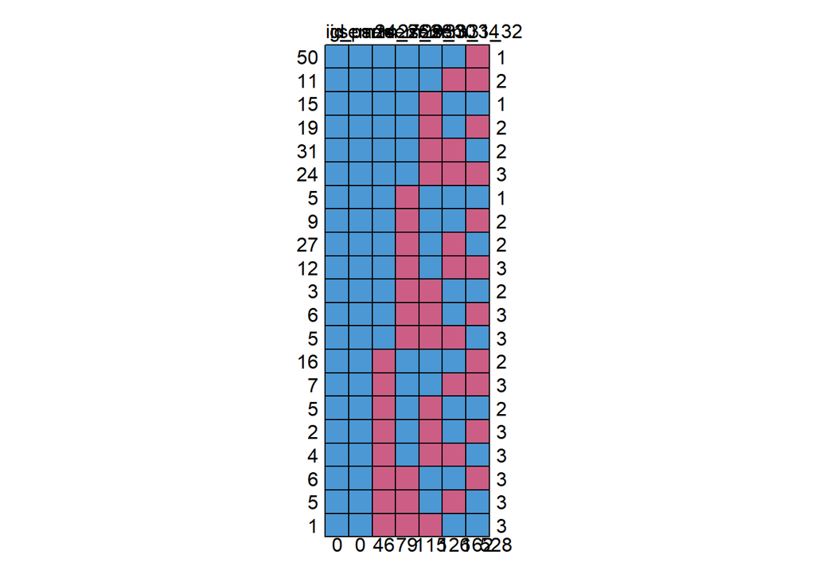

```
   id ig_parto sem24_26 sem27_28 sem29_30 sem33_34 sem31_32
50  1        1        1        1        1        1        0   1
11  1        1        1        1        1        0        0   2
15  1        1        1        1        0        1        1   1
19  1        1        1        1        0        1        0   2
31  1        1        1        1        0        0        1   2
24  1        1        1        1        0        0        0   3
5   1        1        1        0        1        1        1   1
9   1        1        1        0        1        1        0   2
27  1        1        1        0        1        0        1   2
12  1        1        1        0        1        0        0   3
3   1        1        1        0        0        1        1   2
6   1        1        1        0        0        1        0   3
5   1        1        1        0        0        0        1   3
16  1        1        0        1        1        1        0   2
7   1        1        0        1        1        0        0   3
5   1        1        0        1        0        1        1   2
2   1        1        0        1        0        1        0   3
4   1        1        0        1        0        0        1   3
6   1        1        0        0        1        1        0   3
5   1        1        0        0        1        0        1   3
1   1        1        0        0        0        1        1   3
    0        0       46       79      115      126      162 528
```

```r
md.pattern(dados_colo)
```

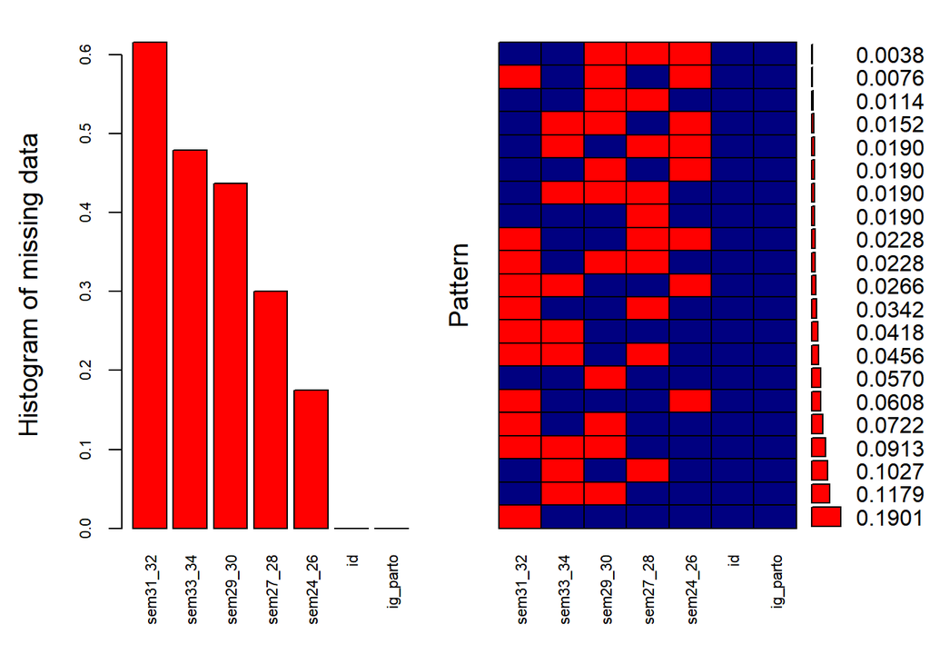

```
 Variables sorted by number of missings:
 Variable     Count
 sem31_32 0.6159696
 sem33_34 0.4790875
 sem29_30 0.4372624
 sem27_28 0.3003802
 sem24_26 0.1749049
       id 0.0000000
 ig_parto 0.0000000
```

```r
aggr_plot <-
  aggr(
    dados_colo,
    col = c('navyblue', 'red'),
    numbers = TRUE,
    sortVars = TRUE,
    labels = names(dados_colo),
    cex.axis = .7,
    gap = 3,
    ylab = c("Histogram of missing data", "Pattern")
  )
```

```r
dados_colo_gather <- gather(
  data = dados_colo,
  key ="ig_aval_sem",
  value =
    "medida_colo",
    "sem24_26",
    "sem27_28",
    "sem29_30",
    "sem31_32",
    "sem33_34"

  )

dados_colo_gather <- dados_colo_gather %>%
  select(-ig_parto)

ids <- unique(dados_colo_gather$id)

#base só com as fixas apenas com dados de pelo menos 2 avaliações do colo
dados_fixas_completo2 <- filter(dados_fixas_completo, id %in% ids)

dados_obs2 <- full_join(dados_fixas_completo2, dados_colo_gather, by= c("id"))

dados_obs2 <- dados_obs2 %>%
  arrange(id, ig_aval_sem)
```

Vamos ver a porcentagem de dados faltantes por idade gestacional:

```r
dados_obs2 %>%
  group_by(ig_aval_sem) %>%
  summarise(nmedida = sum(is.na(medida_colo))/n())
```

```
# A tibble: 5 x 2
  ig_aval_sem nmedida
  <chr>         <dbl>
1 sem24_26      0.175
2 sem27_28      0.300
3 sem29_30      0.437
4 sem31_32      0.616
5 sem33_34      0.479
```

O próximo passo é ajustar modelo de regressão misto para medida do colo. Antes do modelo, vamos ver o histograma e boxplot da medida do colo.

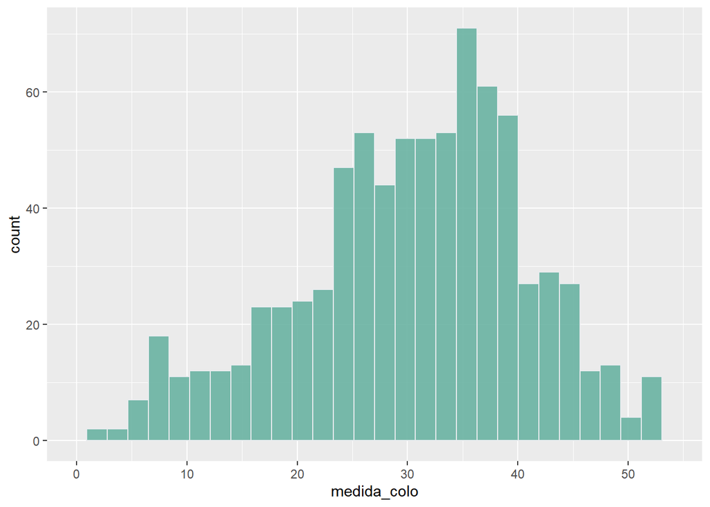

```r
ggplot(data = dados_obs2, aes(x = medida_colo)) +
  geom_histogram(fill = "#69b3a2",
                 color = "#e9ecef",
                 alpha = 0.9) +
  scale_x_continuous(limits = c(0, 54), breaks = seq(0, 54, 10)) +
  theme(plot.title = element_text(size = 15))
```

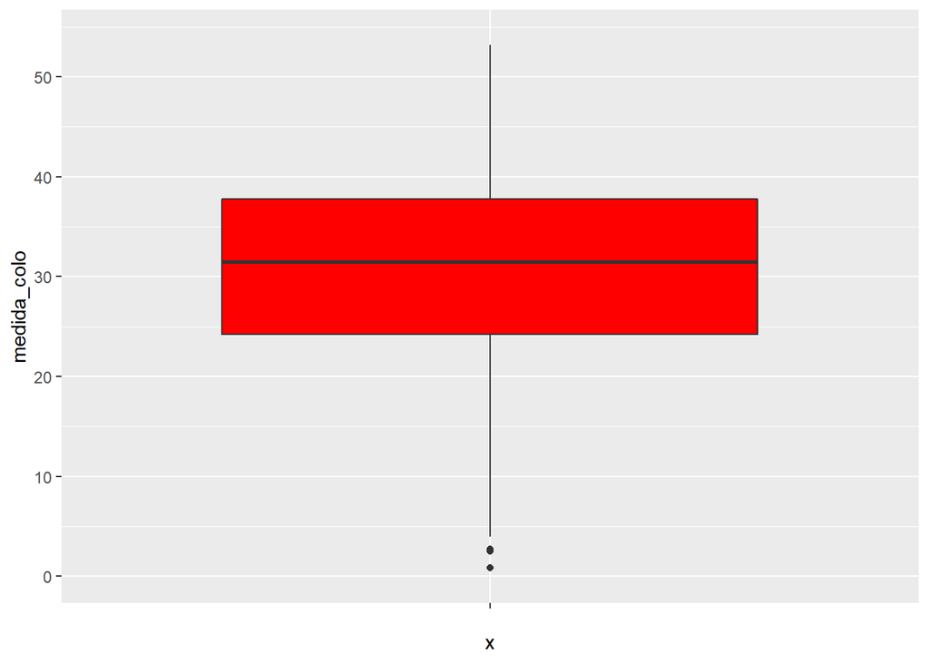

```r
ggplot(data = dados_obs2, aes(y = medida_colo, x = "")) +
  geom_boxplot(fill = "red") +
  scale_y_continuous(limits = c(0, 54), breaks = seq(0, 54, 10)) +
  theme(plot.title = element_text(size = 15))
```

**Modelo para medida do colo:**

```r
aj1 <- lme(medida_colo ~
             ig_aval_sem +
             ovulos +
             corion +
             im +
             tescola +
             cor_branco +
             imc +
             gesta +
             ind_ap +
             hv_tabagismo +
             hv_alcool +
             hv_drogas,
             random = ~ 1|id,
             data = dados_obs2,
             na.action = na.omit)
#summary(aj1)

aj2 <- lme(medida_colo ~
             ig_aval_sem +
             im +
             cor_branco +
             imc,
             random = ~ 1|id,
             data = dados_obs2,
             na.action = na.omit)
summary(aj2)
```

```
Linear mixed-effects model fit by REML
 Data: dados_obs2
       AIC      BIC    logLik
  5328.064 5374.644 -2654.032

Random effects:
 Formula: ~1 | id
        (Intercept) Residual
StdDev:    7.959795 4.953601

Fixed effects: medida_colo ~ ig_aval_sem + im + cor_branco + imc
                         Value Std.Error  DF    t-value p-value
(Intercept)          14.733479  3.497982 520   4.211994  0.0000
ig_aval_semsem27_28  -2.920283  0.519441 520  -5.621970  0.0000
ig_aval_semsem29_30  -5.401411  0.566028 520  -9.542661  0.0000
ig_aval_semsem31_32  -6.903827  0.648441 520 -10.646804  0.0000
ig_aval_semsem33_34 -10.725818  0.580606 520 -18.473497  0.0000
im                    0.289667  0.087878 259   3.296244  0.0011
cor_brancosim         2.910761  1.057278 259   2.753071  0.0063
imc                   0.398352  0.109366 259   3.642367  0.0003
 Correlation:
                    (Intr) i__27_ i__29_ i__31_ i__33_ im     cr_brn
ig_aval_semsem27_28 -0.079
ig_aval_semsem29_30 -0.052  0.396
ig_aval_semsem31_32 -0.056  0.332  0.302
ig_aval_semsem33_34 -0.058  0.420  0.398  0.277
im                  -0.586  0.014 -0.011 -0.012  0.000
cor_brancosim       -0.136  0.003 -0.009 -0.002 -0.004 -0.062
imc                 -0.679  0.003 -0.002  0.016 -0.002 -0.147  0.013

Standardized Within-Group Residuals:
       Min         Q1        Med         Q3        Max
-5.3143484 -0.4819799 -0.0154134  0.4858558  3.2603420

Number of Observations: 787
Number of Groups: 263
```

```r
xnam <- c("ig_aval_sem", "im", "cor_branco", "imc")
fmla <- as.formula(paste("medida_colo ~ ", paste(xnam, collapse= "+"), paste("+ (1|id)",collapse= "+")))

aj <- lmer(fmla, data = dados_obs2, na.action = na.omit)
pred <- predict(aj, newdata = dados_obs2, re.form=NA)

dados_obs2 <- dados_obs2 %>%
  mutate(medida_colo_compl = ifelse(
    is.na(medida_colo), pred, medida_colo)
    )
```

## Imputação para número de contrações

Agora vamos realizar uma análise de dados faltantes.

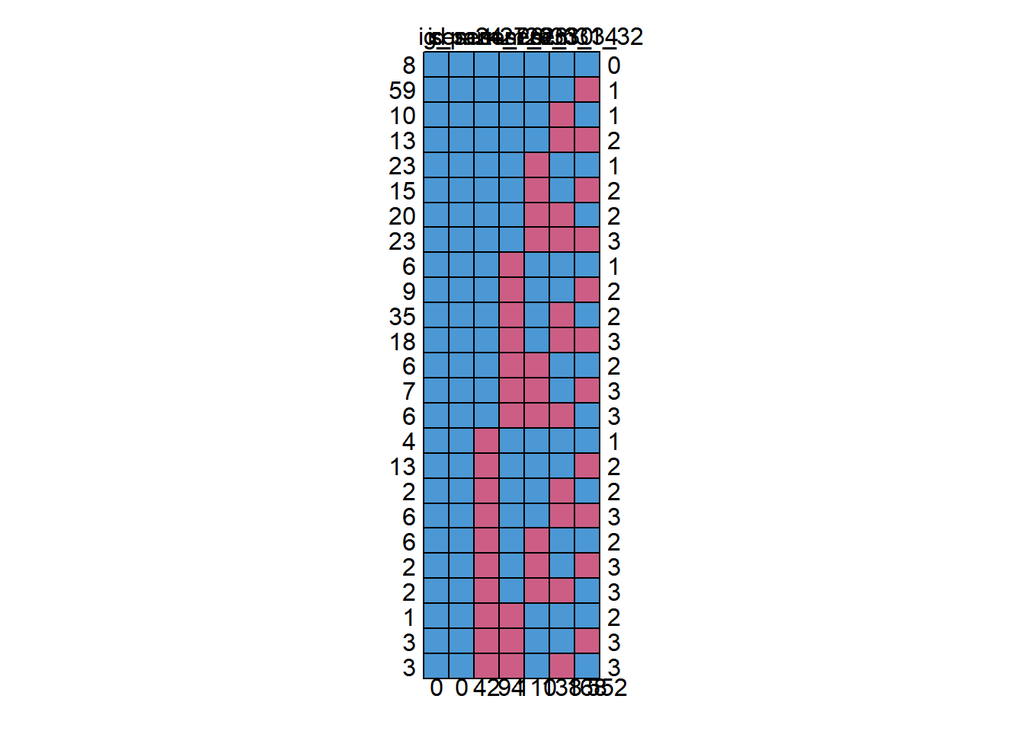

```
   id ig_parto sem24_26 sem27_28 sem29_30 sem33_34 sem31_32
8   1        1        1        1        1        1        1   0
59  1        1        1        1        1        1        0   1
10  1        1        1        1        1        0        1   1
13  1        1        1        1        1        0        0   2
23  1        1        1        1        0        1        1   1
15  1        1        1        1        0        1        0   2
20  1        1        1        1        0        0        1   2
23  1        1        1        1        0        0        0   3
6   1        1        1        0        1        1        1   1
9   1        1        1        0        1        1        0   2
35  1        1        1        0        1        0        1   2
18  1        1        1        0        1        0        0   3
6   1        1        1        0        0        1        1   2
7   1        1        1        0        0        1        0   3
6   1        1        1        0        0        0        1   3
4   1        1        0        1        1        1        1   1
13  1        1        0        1        1        1        0   2
2   1        1        0        1        1        0        1   2
6   1        1        0        1        1        0        0   3
6   1        1        0        1        0        1        1   2
2   1        1        0        1        0        1        0   3
2   1        1        0        1        0        0        1   3
1   1        1        0        0        1        1        1   2
3   1        1        0        0        1        1        0   3
3   1        1        0        0        1        0        1   3
    0        0       42       94      110      138      168 552
```

```r
md.pattern(dados_num_contra)
```

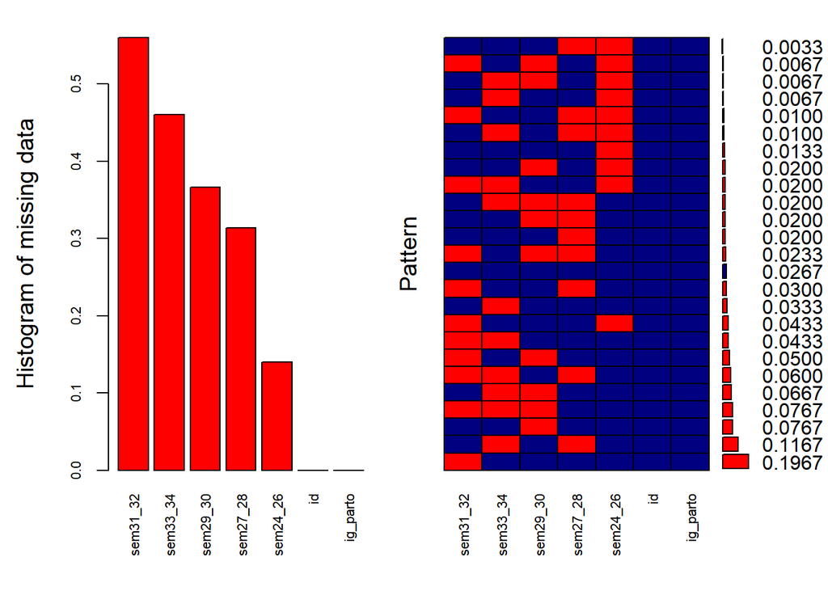

```
 Variables sorted by number of missings:
 Variable     Count
 sem31_32 0.5600000
 sem33_34 0.4600000
 sem29_30 0.3666667
 sem27_28 0.3133333
 sem24_26 0.1400000
       id 0.0000000
 ig_parto 0.0000000
```

```r
aggr_plot <-
  aggr(
    dados_num_contra,
    col = c('navyblue', 'red'),
    numbers = TRUE,
    sortVars = TRUE,
    labels = names(dados_num_contra),
    cex.axis = .7,
    gap = 3,
    ylab = c("Histogram of missing data", "Pattern")
  )
```

```r
dados_contra_gather <- gather(
  data = dados_num_contra,
  key ="ig_aval_sem",
  value = "num_contra",
          "sem24_26",
          "sem27_28",
          "sem29_30",
          "sem31_32",
          "sem33_34")

dados_contra_gather <- dados_contra_gather %>%
  select(-ig_parto)

ids <- unique(dados_contra_gather$id)

#base só com as fixas soh com dados de pelo menos 2 avaliações do colo
dados_fixas_completo3 <- filter(dados_fixas_completo, id %in% ids)

dados_obs3 <- full_join(dados_fixas_completo3, dados_contra_gather, by= c("id"))

dados_obs3 <- dados_obs3 %>%
  arrange(id, ig_aval_sem)
```

Vamos ver a porcentagem de dados faltantes por idade gestacional:

```r
dados_obs3 %>%
  group_by(ig_aval_sem) %>%
  summarise(ncontra = sum(is.na(num_contra))/n()
            )
```

```
# A tibble: 5 x 2
  ig_aval_sem ncontra
  <chr>         <dbl>
1 sem24_26      0.14
2 sem27_28      0.313
3 sem29_30      0.367
4 sem31_32      0.56
5 sem33_34      0.46
```

O próximo passo é ajusta modelo de contagem misto para número de contrações. Antes do modelo, vamos ver o histograma e boxplot.

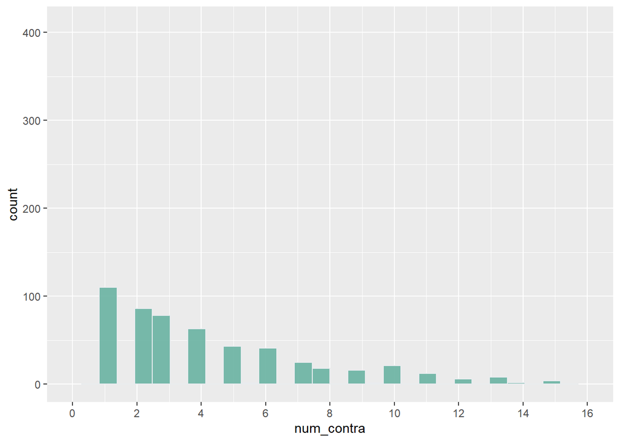

```r
ggplot(data = dados_obs3, aes(x = num_contra)) +
  geom_histogram(fill = "#69b3a2",
                 color = "#e9ecef",
                 alpha = 0.9) +
  scale_x_continuous(limits = c(0, 16), breaks = seq(0, 16, 2)) +
  theme(plot.title = element_text(size = 15))
```

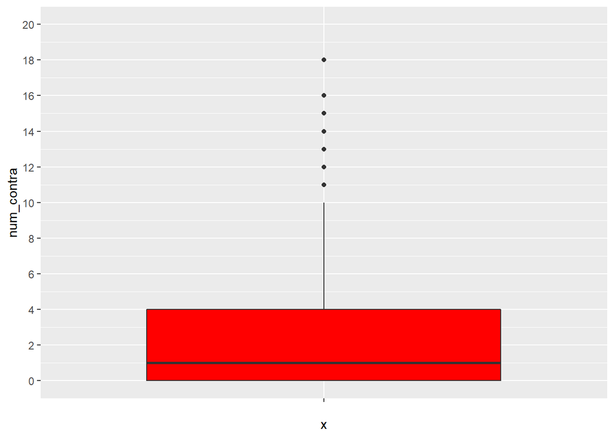

```r
ggplot(data = dados_obs3, aes(y = num_contra, x = "")) +
  geom_boxplot(fill = "red") +
  scale_y_continuous(limits = c(0, 20), breaks = seq(0, 20, 2)) +
  theme(plot.title = element_text(size = 15))
```

Vamos remover os outliers de número de contrações:

```r
dados_obs3 <- dados_obs3 %>%
  mutate(num_contra1 = ifelse(num_contra <= 10, num_contra, NA_integer_)
    )
```

```r
nbm1 <- glmmTMB(num_contra1 ~
                  ig_aval_sem +
                  ovulos +
                  corion +
                  im +
                  tescola +
                  cor_branco +
                  imc +
                  gesta +
                  ind_ap +
                  hv_tabagismo +
                  hv_alcool +
                  hv_drogas +
                  (1 | id),
                  data = dados_obs3,
                  family = nbinom2)  #summary(nbm1)

nbm2 <- glmmTMB(num_contra1 ~
                  ig_aval_sem +
                  ovulos +
                  corion +
                  im +
                  tescola +
                  cor_branco +
                  imc  +
                  (1 | id),
                  data = dados_obs3,
                  family = nbinom2)  #summary(nbm2)

nbm3 <- glmmTMB(num_contra1 ~
                  ig_aval_sem +
                  corion +
                  im   +
                  cor_branco +
                  imc  +
                  (1 | id),
                  data = dados_obs3,
                  family = nbinom2)  #summary(nbm3)

nbm4 <- glmmTMB(num_contra1 ~
                  ig_aval_sem +
                  im   +
                  cor_branco +
                  imc  +
                  (1 | id),
                  data = dados_obs3,
                  family = nbinom2)   #summary(nbm4)

nbm5 <- glmmTMB(num_contra1 ~
                  ig_aval_sem +
                  im +
                  imc +
                  (1 | id),
                  data = dados_obs3,
                  family = nbinom2)  #summary(nbm5)

nbm8 <- glmmTMB(num_contra1 ~
                  ig_aval_sem +
                  im  +
                  imc  +
                  (1 | id),
                  data = dados_obs3,
                  family = nbinom2)
summary(nbm8)
```

```
 Family: nbinom2  ( log )
Formula:          num_contra1 ~ ig_aval_sem + im + imc + (1 | id)
Data: dados_obs3

     AIC      BIC   logLik deviance df.resid
  3357.1   3400.4  -1669.5   3339.1      903

Random effects:

Conditional model:
 Groups Name        Variance Std.Dev.
 id     (Intercept) 0.4222   0.6498
Number of obs: 912, groups:  id, 300

Overdispersion parameter for nbinom2 family (): 1.21

Conditional model:
                     Estimate Std. Error z value Pr(>|z|)
(Intercept)          1.657908   0.398865   4.157 3.23e-05 ***
ig_aval_semsem27_28  0.661264   0.136855   4.832 1.35e-06 ***
ig_aval_semsem29_30  1.083273   0.136488   7.937 2.08e-15 ***
ig_aval_semsem31_32  1.351299   0.148832   9.079  < 2e-16 ***
ig_aval_semsem33_34  1.595767   0.142089  11.231  < 2e-16 ***
im                  -0.015294   0.009604  -1.592    0.111
imc                 -0.064752   0.012545  -5.162 2.45e-07 ***
---
Signif. codes:  0 '***' 0.001 '**' 0.01 '*' 0.05 '.' 0.1 ' ' 1
```

```r
pred_infl <- predict(nbm8,newdata = dados_obs3,  type ="response", re.form=NA)

dados_obs3 <- dados_obs3 %>%
  mutate(pred_infl = pred_infl
    )
```

```r
gm1 <- glmer(num_contra1 ~
               ig_aval_sem +
               im +
               imc +
               (1 | id),
               data = dados_obs3,
               family = "poisson")

pred_glmer <- predict(gm1, newdata = dados_obs3,  type ="response", re.form=NA)

dados_obs3 <- dados_obs3 %>%
  mutate(pred_glmer = pred_glmer
  )
```

Vamos ver o resíduo:

```r
dados_obs3 <- dados_obs3 %>%
  mutate(res_infl = num_contra1 - pred_infl,
    res_glmer = num_contra1 - pred_glmer,
    res_infl_abs = abs(num_contra1 - pred_infl),
    res_glmer_abs = abs(num_contra1 - pred_glmer)
    )

summary(dados_obs3$res_glmer)
```

```
   Min. 1st Qu.  Median    Mean 3rd Qu.    Max.    NA's
-4.5461 -1.1390 -0.5063  0.4138  1.5394  9.3211     588
```

```r
summary(dados_obs3$res_infl)
```

```
   Min. 1st Qu.  Median    Mean 3rd Qu.    Max.    NA's
-5.7596 -1.2617 -0.5272  0.2372  1.3286  9.3466     588
```

```r
summary(dados_obs3$res_glmer_abs)
```

```
   Min. 1st Qu.  Median    Mean 3rd Qu.    Max.    NA's
 0.0014  0.6932  1.2565  1.8120  2.2571  9.3211     588
```

```r
summary(dados_obs3$res_infl_abs)
```

```
   Min. 1st Qu.  Median    Mean 3rd Qu.    Max.    NA's
 0.0017  0.6504  1.2817  1.8126  2.3730  9.3466     588
```

Acho que podemos ficar com nbm8. Os resíduos são similares e o glmer tem problema de convergência.

##### Concatenar as medidas

Vamos ver se os dados válidos de medida do colo (dados_obs2) estão em num de contra (dados_obs3):

```r
ids_numcontra <- unique(dados_obs3$id)
sum(!(dados_obs2$id %in% ids_numcontra))
```

```
[1] 0
```

Pelo resultado acima, observamos que todos os casos que estão na base de dados de medida do colo estão também na base de dados válidos de número de contrações.

```r
dados_obs3_aux <- dados_obs3 %>%
  select(id, ig_aval_sem, num_contra)

dados_igs_completas <- inner_join(dados_obs2, dados_obs3_aux, by = c("id", "ig_aval_sem"))
# length(unique(dados_igs_completas$id))
# str(dados_igs_completas)
```

Vamos agora imputar os dados de medida do colo e de num de contrações.

```r
pred_colo <- predict(aj, newdata = dados_igs_completas, re.form = NA)

pred_contra <-
  predict(nbm8,
          newdata = dados_igs_completas,
          type = "response",
          re.form = NA)

dados_igs_completas <- dados_igs_completas %>%
    mutate(medida_colo_imp = ifelse(
    is.na(medida_colo), pred_colo, medida_colo),
    num_contra_imp = ifelse(
    is.na(num_contra), pred_contra, num_contra)
    )
```

```r
write_xlsx(dados_igs_completas, "dados_igs_completas_5avals.xlsx")
```